# Perth COVID-19 study; journey to work census analysis

Perth COVID-19 study; journey to work census analysis

Dr James Reynolds, Monash University Public Transport Research Group (PTRG)

2023-06-15

# 1.0 Introduction

Monash University’s Public Transport Research Group (PTRG) is looking at changes in travel behaviour in Perth surrounding the COVID-19 pandemic. Part of this work involves examining the Australian Bureau of Statistics (ABS) journey-to-work data for the 2016 and 2021 censuses. Areas of interest are:

- an aggregate analysis for all of the Greater Perth area;
- a disaggregate analysis for three groupings of Perth Local Government Areas (LGAs) defined in previous PTRG work as: the North-south grouping, the Heritage grouping and the Outer-east grouping.

  City of Melville, City of South Perth, City of Stirling, City of Joondalup, City of Wanneroo, City of Cockburn, City of Kwinana, City of Rockingham, City of Murray and City of Mandurah.

  City of Bayswater, City of Belmont, City of Canning, City of Fremantle, City of Nedlands, City of Perth, City of Subiaco, City of Vincent, Shire of Peppermint Grove, Town of Bassendean, Town of Cambridge, Town of Claremont, Town of Cottesloe, Town of East Fremantle, Town of Mosman Park, Town of Victoria Park and City of Gosnells.

  City of Kalamunda, City of Swan, Shire of Mundaring, City of Armadale, and Shire of Serpentine-Jarrahdale.
- Perth CBD / non-CBD-based Jobs, for all of Greater Perth and for the North-south, Heritage and Outer-east groupings

  Here the central City of Perth is adopted.

This working note details the process of collecting and reviewing the ABS data. It is structured as follows: the next section details the processing of the ABS data; Section 3 presents the results; followed by a brief discussion in Section 4; and conclusions in Section 5.

# 2.0 Methods and data

The census provides data at a range of geographical scales and levels of detail. Ideally for this analysis the data would be downloaded at the lowest scale of interest, and then aggregated to larger areas. However, a problem is that random alternations are made by the census to cells with small values so that individuals cannot be identified. Hence, aggregation will only combine these errors. Therefore it is necessary to download the data multiple times, at the highest geographical level needed for each part of the analsis.

For example, get the census data at LGA level for place of usual residence and place of work, then aggregate up to the three groupings and Greater Perth.

As this analysis is looking at 15 different JTW modes there will be a lot of small cells.

## 2.1 JTW for Greater Perth (usual residence)

Data tables for the 2016 and 2021 census were obtained for the journey to work mode for all of Greater Perth.

See Greater_Perth_UR_JTW_2016.csv and Greater_Perth_UR_JTW_2021.csv

## 2.2 JTW for by LGA (usual residence)

Data tables for the 2016 and 2021 census were obtained for the journey to work mode by LGA of Usual Residence (UR) and LGA of Place Of Work (POW). The CSV files provide the LGA POW and mode volumes for each LGA UR in turn. To get these into a usable format the Table_Builder_Reader tool was used.

For LGAs within Western Australia only.

For all LGAs in Australia.

See Greater_Perth_JTW_by_DZ_and_LGA_2016.csv and Greater_Perth_JTW_by_DZ_and_LGA_2021.csv.

i.e. a separate CSV file for each LGA UR.

See https://github.com/vlc/table_builder_io/

The “Total” row was extracted from each CSV file, to provide total mode volumes for each LGA of UR. The Heritage, North-south and Outer east groupings were added to the datasets.

## 2.3 JTW by LGA (usual residence) and LGA (place of work)

The same data tables were used as in Section 2.2 above, but this time the individual LGA POW rows were retained. The Heritage, North-south and Outer east groupings were added to the datasets as before, but a Place Of Work (POW) variable was also defined.

CBD (the City of Perth), the Rest of Greater Perth, and other places (rest of WA, rest of Australia).

The Heritage, North-south and Outer east groupings were added to the datasets. A Place Of Work (POW) variable was also defined.

CBD (the City of Perth), the Rest of Greater Perth, and other places (rest of WA, rest of Australia).

## 2.4 Population and employment data

The age and employment data was also obtained so that population and employed population changes can be calculated for each of the Heritage, North-south and Outer east groupings. Note that the employment figures include all people who are employed or studying.

See 2016_WA_Age_by_LGA.csv, 2021_WA_Age_by_LGA.csv, 2016_WA_employment_by_LGA.csv, 2021_WA_employment_by_LGA.csv.

See definitions at https://www.abs.gov.au/census/guide-census-data/census-dictionary/2021/variables-topic/education-and-training/engagement-employment-education-and-training-eetp

# 3.0 Results

## 3.1 Aggregate for Greater Perth

The following shows aggregate results for all people whose usual residence was within Greater Perth at the time of each census. Looking at the population and employment numbers:

Note that the employment numbers include people who are engaged in employment and study.

Population and employed population, Greater Perth, 2016 and 2021

| Year | Population | Employed |
| --- | --- | --- |
| 2016 | 1864411 | 981806 |
| 2021 | 2033316 | 1102125 |

The population rose by 168,905 (9.1%), while the number of people employed and/or studying increased by 120,319 (12.3%).

| Year | private_vehicle_drive | private_vehicle_passenger | transit | non_motorised | other_mode | worked_at_home | did_not_go_to_work | not_stated | not_applicable | Total |
| --- | --- | --- | --- | --- | --- | --- | --- | --- | --- | --- |
| 2016 | 31.1% (605,199) | 2.3% (44,875) | 4.9% (94,912) | 1.5% (28,366) | 0.6% (11,265) | 1.8% (35,528) | 4.7% (91,187) | 0.5% (8,849) | 52.7% (1,023,661) | 100.0% (1,943,842) |
| 2021 | 31.7% (670,135) | 2.5% (52,331) | 4.2% (89,541) | 1.1% (23,659) | 0.7% (14,942) | 3.8% (80,658) | 5.8% (123,429) | 0.2% (4,194) | 50.0% (1,057,758) | 100.0% (2,116,647) |

People with a usual residence in Greater Perth, journey to work mode share, 2021 and 2016 censuses

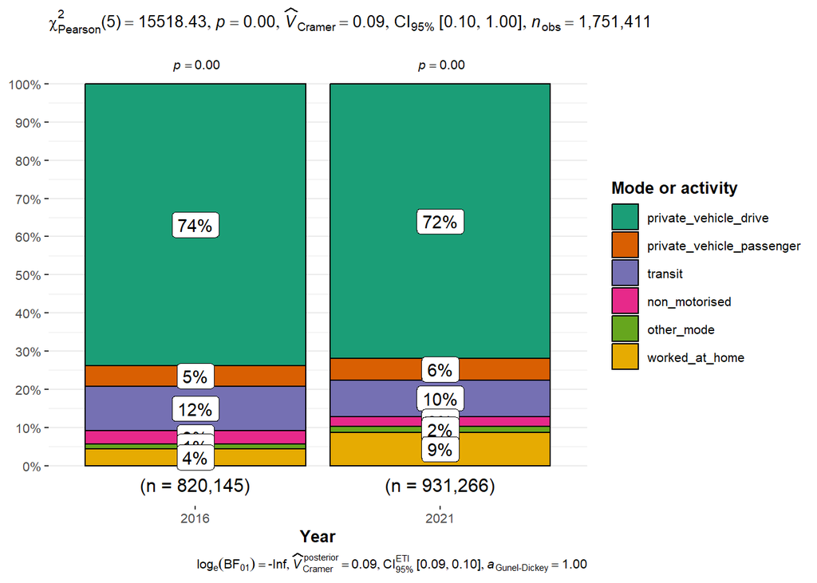

Journey to work mode/activity shares, persons with a usual residence inGreater Perth, 2016 and 2021 censuses; excluding did not go to work, notstated and not applicable

| Year | Drive | Passenger | Transit | Walk/Bike | Other | WFH | Total |
| --- | --- | --- | --- | --- | --- | --- | --- |
| 2016 | 73.8% (605,199) | 5.5% (44,875) | 11.6% (94,912) | 3.5% (28,366) | 1.4% (11,265) | 4.3% (35,528) | 100.0% (820,145) |
| 2021 | 72.0% (670,135) | 5.6% (52,331) | 9.6% (89,541) | 2.5% (23,659) | 1.6% (14,942) | 8.7% (80,658) | 100.0% (931,266) |

A Pearson’s chi-squared test indicated that the relationship between census and JTW activity/mode was significant $\chi^2(5, N = 1751411) = 15518.43$, $p < .001$.

The number of people who worked from home also increased by a large amount, more than doubling to 80,658 (+45,130, 127%). WFH share increased by 4.3% to 8.7%.

The number of people who commuted as a passenger in a private vehicle increased by 7,456(+17%). Again, the rate of this increase is much larger than the rate of increase in population (9.1%) and than the rate of increase in the number of people who were employed and/or studying (12.3%). However, passenger mode share was relatively stable, only increasing by 0.1%.

The use of non-motorised modes dropped, with the number of people cycling and walking falling by 4,707(-17%). The non-motorised mode share also fell by a small amount (-0.9%).

Transit ridership fell (-5,371, -6%) as did the transit mode share (-2.0%). The following summarizes the changes amongst the individual transit modes:

Greater Perth, journey to work mode share by train and bus, 2021 and 2016 censuses

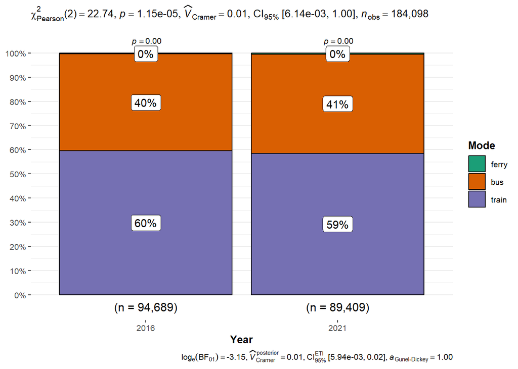

Journey to work mode shares for transit, persons with a usual residencein Greater Perth, 2016 and 2021 censuses; excluding did not go to work,not stated and not applicable

| Year | train | bus | ferry | tram | Total |
| --- | --- | --- | --- | --- | --- |
| 2016 | 59.4% (56,417) | 39.9% (37,899) | 0.4% (373) | 0.2% (223) | 100.0% (94,912) |
| 2021 | 58.4% (52,327) | 41.0% (36,687) | 0.4% (395) | 0.1% (132) | 100.0% (89,541) |

Journey to work mode shares, persons with a usual residence in GreaterPerth, 2016 and 2021 censuses; excluding did not go to work, not statedand not applicable

| Year | train | bus | ferry | tram | private_vehicle_drive | private_vehicle_passenger | non_motorised | other_mode | worked_at_home | Total |
| --- | --- | --- | --- | --- | --- | --- | --- | --- | --- | --- |
| 2016 | 6.9% (56,417) | 4.6% (37,899) | 0.0% (373) | 0.0% (223) | 73.8% (605,199) | 5.5% (44,875) | 3.5% (28,366) | 1.4% (11,265) | 4.3% (35,528) | 100.0% (820,145) |
| 2021 | 5.6% (52,327) | 3.9% (36,687) | 0.0% (395) | 0.0% (132) | 72.0% (670,135) | 5.6% (52,331) | 2.5% (23,659) | 1.6% (14,942) | 8.7% (80,658) | 100.0% (931,266) |

A Pearson’s chi-squared test indicated that the relationship between census and the shares of train, bus and ferry ridership was significant $\chi^2(2, N = 184098) = 22.74$, $p < .001$.

The number of people who used the train fell by 4,090(7%). Train ridership as a share of transit ridership decreased by 1.0% to 58.4%. The overall train mode share also dropped (by 1.3% to 5.6%).

Bus ridership fell by a similar amount (1,212, 3%), but bus ridership rose as a share of transit ridership by 1.0% to 41.0%. The overall bus mode share fell by 0.7% to 3.9%.

## 3.2 Disaggregate

The following sections discuss the changes in JTW commute mode/activity for people whose usual residence was in the eith the Heritiage, the North-south or the Outer-east groupings of LGAs.

### 3.2.1 Heritage grouping

Changes in the population and population engaged in employment and/or study within the Heritage grouping of LGAs between the 2016 and 2021 censuses are as follows:

Population and employed population, Heritage grouping, 2016 and 2021

| Year | Population | Employed |
| --- | --- | --- |
| 2016 | 496976 | 270945 |
| 2021 | 534177 | 300973 |

The population of the Heritage grouping of LGAs rose by 37,201 (7.5%), while the number of people employed and/or studying increased by 30,028 (11.1%).

| Year | private_vehicle_drive | private_vehicle_passenger | transit | non_motorised | other_mode | worked_at_home | did_not_go_to_work | not_stated | not_applicable | Total |
| --- | --- | --- | --- | --- | --- | --- | --- | --- | --- | --- |
| 2016 | 29.5% (162,376) | 2.3% (12,876) | 6.2% (33,884) | 2.6% (14,473) | 0.5% (2,812) | 1.9% (10,512) | 4.4% (24,206) | 0.4% (2,473) | 52.1% (286,175) | 100.0% (549,787) |
| 2021 | 30.4% (179,016) | 2.7% (15,770) | 5.6% (33,242) | 2.1% (12,460) | 0.6% (3,647) | 4.2% (24,801) | 5.5% (32,306) | 0.2% (1,221) | 48.7% (287,176) | 100.0% (589,639) |

Heritage grouping, journey to work mode share, 2021 and 2016 censuses

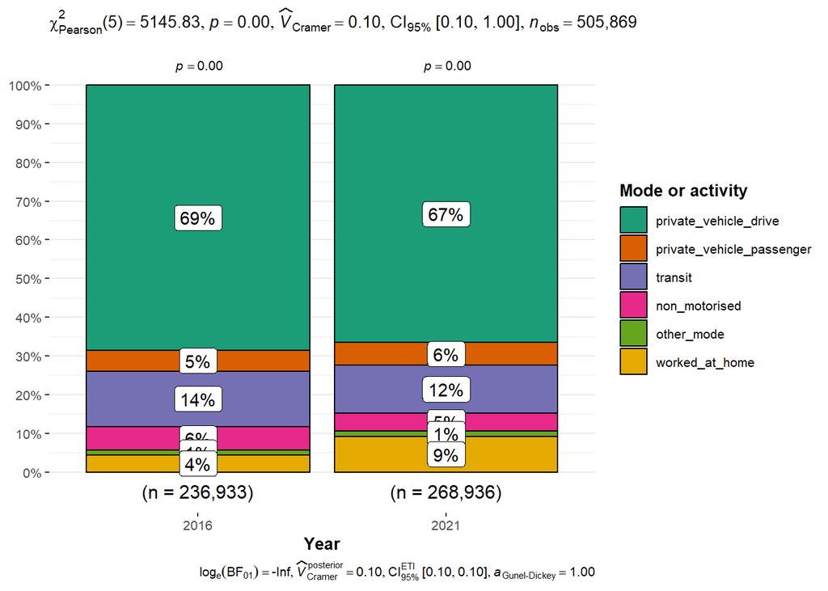

Journey to work mode/activity shares, persons with a usual residence inthe Heritage grouping, 2016 and 2021 censuses; excluding did not go towork, not stated and not applicable

| Year | Drive | Passenger | Transit | Walk/Bike | Other | WFH | Total |
| --- | --- | --- | --- | --- | --- | --- | --- |
| 2016 | 68.5% (162,376) | 5.4% (12,876) | 14.3% (33,884) | 6.1% (14,473) | 1.2% (2,812) | 4.4% (10,512) | 100.0% (236,933) |
| 2021 | 66.6% (179,016) | 5.9% (15,770) | 12.4% (33,242) | 4.6% (12,460) | 1.4% (3,647) | 9.2% (24,801) | 100.0% (268,936) |

A Pearson’s chi-squared test indicated that the relationship between census and JTW activity/mode was significant $\chi^2(5, N = 505869) = 5145.83$, $p < .001$.

The number of people whose usual residence is in the Heritage grouping of LGAs and who commuted in a private vehicle as the driver increased by 16,640(+10%). This rate is higher than that of population growth (7.5%), but slightly lower than the growth in people who are employed or studying (11.1%). However, the drive mode share dropped slightly (-2.0%) to 66.6%.

The number of people whose usuual residence is in the Heritage grouping of LGas who worked from home increased by 14,289(136%). WFH share increased by 4.8% to 9.2%.

The rate of increase in the number of people whose usual residence is in the Heritage grouping of LGAs who commuted as a passenger in a private vehicle (+22%, +2,894 people) was roughly twice the rate of the increase in the number of people who were employed or studying (+11.1%). However, overall passenger mode share only increased by 0.4%.

Transit ridership fell slightly (-642, -2%), with transit mode share also dropping (-1.9%). However, it is important to note that the Freemantle line was scheduled to be fully closed on the day of the census ]

See https://chartingtransport.com/category/mode-share/ which may be part of the reason for the drop in transit ridership

The following shows changes in ridership amongst each transit mode:

Heritage grouping, journey to work mode share for transit, 2021 and 2016 censuses

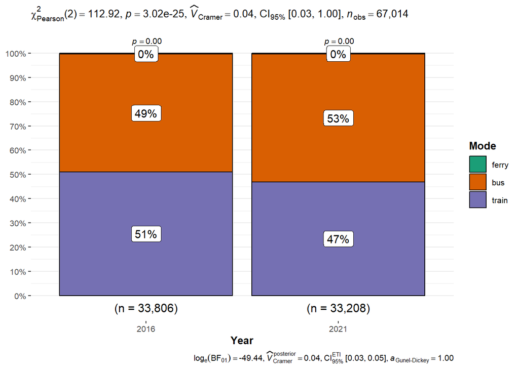

Journey to work mode shares for transit, persons with a usual residencein Heritage grouping, 2016 and 2021 censuses; excluding did not go towork, not stated and not applicable

| Year | train | bus | ferry | tram | Total |
| --- | --- | --- | --- | --- | --- |
| 2016 | 50.8% (17,223) | 48.7% (16,486) | 0.3% (97) | 0.2% (78) | 100.0% (33,884) |
| 2021 | 46.8% (15,560) | 52.8% (17,557) | 0.3% (91) | 0.1% (34) | 100.0% (33,242) |

Journey to work transit mode shares, persons with a usual residence inHeritage grouping, 2016 and 2021 censuses

| Year | train | bus | ferry | tram | private_vehicle_drive | private_vehicle_passenger | non_motorised | other_mode | worked_at_home | Total |
| --- | --- | --- | --- | --- | --- | --- | --- | --- | --- | --- |
| 2016 | 7.3% (17,223) | 7.0% (16,486) | 0.0% (97) | 0.0% (78) | 68.5% (162,376) | 5.4% (12,876) | 6.1% (14,473) | 1.2% (2,812) | 4.4% (10,512) | 100.0% (236,933) |
| 2021 | 5.8% (15,560) | 6.5% (17,557) | 0.0% (91) | 0.0% (34) | 66.6% (179,016) | 5.9% (15,770) | 4.6% (12,460) | 1.4% (3,647) | 9.2% (24,801) | 100.0% (268,936) |

Despite the fall in overall transit ridership (-642), the number of commuters living in the Heritage grouping who used the bus rose by 1,071 (6%). Bus ridership rose as a share of transit ridership by 4.2% to 52.8%. However, the overall bus mode share fell by 0.4% to 6.5%.

The number of people who used the train fell by 1,663(10%). Train ridership as a share of transit ridership also fell, dropping 4.0% to 46.8%. The overall train mode share dropped by 1.5% to 5.8%. However, again it is important to note that the Freemantle line was scheduled to be fully closed on the day of the census .

See https://chartingtransport.com/category/mode-share/ which may be part of the reason for the drop in train (and perhaps also bus) ridership.

Notably, the drop in the number of people commuting by non-motorised modes (walk or bike) was 3.1 times larger than the loss in transit ridership, with 2,013 fewer people walking or cycling to work in 2021 than in 2016 (equating to a fall of 14%). Non-motorised mode share also dropped to 4.6%(-1.5%).

### 3.2.2 North-south grouping

The following shows results for all people whose usual residence was within the North-south grouping of LGAs.

Population and employed population, North-south grouping, 2016 and 2021

| Year | Population | Employed |
| --- | --- | --- |
| 2016 | 1016890 | 531473 |
| 2021 | 1107061 | 595359 |

The population of the North-south grouping of LGAs rose by 90,171 (+8.9%). The number of people employed and/or studying whose usual residence was in the North-south grouping increased by 63,886 (+12.0%).

| Year | private_vehicle_drive | private_vehicle_passenger | transit | non_motorised | other_mode | worked_at_home | did_not_go_to_work | not_stated | not_applicable | Total |
| --- | --- | --- | --- | --- | --- | --- | --- | --- | --- | --- |
| 2016 | 31.4% (332,338) | 2.3% (24,403) | 4.8% (50,374) | 1.0% (11,022) | 0.6% (6,447) | 1.8% (19,159) | 4.8% (51,222) | 0.5% (4,814) | 52.8% (559,170) | 100.0% (1,058,949) |
| 2021 | 31.7% (365,130) | 2.4% (27,773) | 4.1% (46,704) | 0.8% (8,725) | 0.7% (8,423) | 3.8% (43,916) | 6.0% (69,375) | 0.2% (2,152) | 50.3% (578,193) | 100.0% (1,150,391) |

North-south grouping, journey to work mode share, 2021 and 2016 censuses

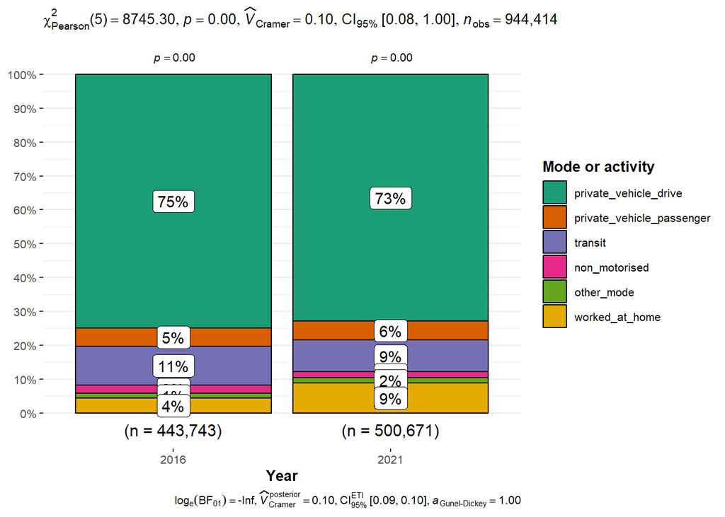

Journey to work mode/activity shares, persons with a usual residence inthe North-south grouping, 2016 and 2021 censuses; excluding did not goto work, not stated and not applicable

| Year | Drive | Passenger | Transit | Walk/Bike | Other | WFH | Total |
| --- | --- | --- | --- | --- | --- | --- | --- |
| 2016 | 74.9% (332,338) | 5.5% (24,403) | 11.4% (50,374) | 2.5% (11,022) | 1.5% (6,447) | 4.3% (19,159) | 100.0% (443,743) |
| 2021 | 72.9% (365,130) | 5.5% (27,773) | 9.3% (46,704) | 1.7% (8,725) | 1.7% (8,423) | 8.8% (43,916) | 100.0% (500,671) |

A Pearson’s chi-squared test indicated that the relationship between census and JTW activity/mode was significant $\chi^2(5, N = 944414) = 8745.30$, $p < .001$.

The number of people whose usual residence was in the North-south grouping of LGAs who drove a private vehicle for their commute increased by 10% (+32,792). This is between the rates of increase for population (+8.9%) and for the number of people engaged in work and/or study (+12.0%). However, overall drive mode share dropped by (2.0%).

The number of people who worked from home increased by 24,757(+129%). WFH share increased by 4.5% to 8.8%.

The number of people who lived in the North-south grouping and commuted as a passenger in a private vehicle increased by 3,370 (+14%). The rate of increase for commuting as a passenger was higher than both that of population growth (8.9%) and the rate of growth in the number of people engaged in employment and/or study in the North-south grouping of LGAs (12.0%). However, overall passenger mode share did not change (remaining at 5.5%).

The number of people who used non-motorised modes dropped by 2,297(21%). Non-motorised mode share also fell (-0.7%) to 1.7%.

Transit ridership amongst those whose usual residence was in the North-south group of LGAs dropped by 3,670(7%). Transit mode share also dropped (-2.0%). The following summarizes the mode split amongst those who used transit:

North-south grouping, journey to work mode share by train, bus and ferry, 2021 and 2016 censuses

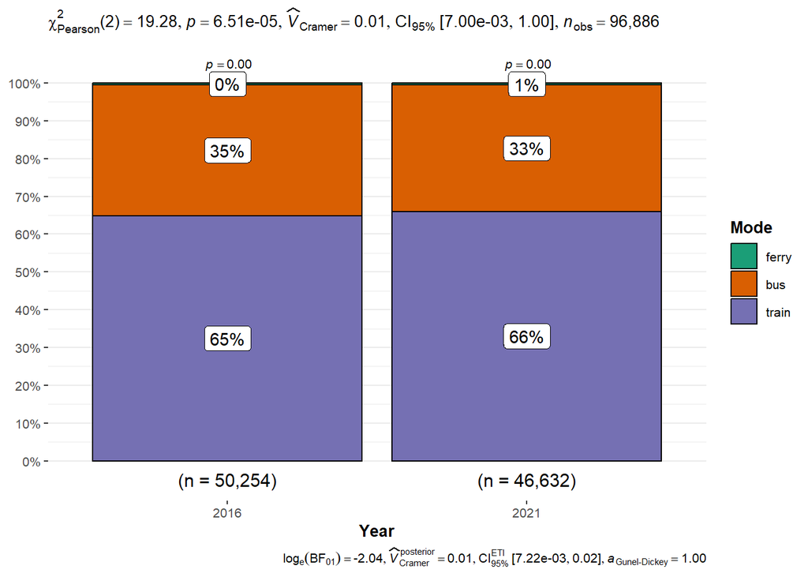

Journey to work mode shares for transit, persons with a usual residencein North-south grouping of LGAs, 2016 and 2021 censuses.

| Year | train | bus | ferry | tram | Total |
| --- | --- | --- | --- | --- | --- |
| 2016 | 64.7% (32,579) | 34.7% (17,456) | 0.4% (219) | 0.2% (120) | 100.0% (50,374) |
| 2021 | 65.9% (30,790) | 33.4% (15,606) | 0.5% (236) | 0.2% (72) | 100.0% (46,704) |

Journey to work mode shares, persons with a usual residence inNorth-south grouping, 2016 and 2021 censuses; excluding did not go towork, not stated and not applicable

| Year | train | bus | ferry | tram | private_vehicle_drive | private_vehicle_passenger | non_motorised | other_mode | worked_at_home | Total |
| --- | --- | --- | --- | --- | --- | --- | --- | --- | --- | --- |
| 2016 | 7.3% (32,579) | 3.9% (17,456) | 0.0% (219) | 0.0% (120) | 74.9% (332,338) | 5.5% (24,403) | 2.5% (11,022) | 1.5% (6,447) | 4.3% (19,159) | 100.0% (443,743) |
| 2021 | 6.1% (30,790) | 3.1% (15,606) | 0.0% (236) | 0.0% (72) | 72.9% (365,130) | 5.5% (27,773) | 1.7% (8,725) | 1.7% (8,423) | 8.8% (43,916) | 100.0% (500,671) |

A Pearson’s chi-squared test indicated that the relationship between census and the shares of train, bus and ferry ridership was significant $\chi^2(2, N = 96886) = 19.28$, $p < .001$.

Bus ridership amongst those with a usual residence within the North-south grouping of LGAs fell by a similar amount (-1,850, -11%). Bus ridership fell as a share of transit ridership (-1.2%) to 33.4%. The overall bus mode share also dropped, falling 0.8% to 3.1%.

### 3.2.3 Outer-east grouping

The following shows results for all people whose usual residence was within the Outer-east grouping of LGAs. Changes in the population and the number of people engaged in work and/or study are shown in the following:

Population and employed population, Outer-east, 2016 and 2021

[output not shown]

Population and employed population changes, Outer-east grouping, 2016and 2021

| Year | private_vehicle_drive | private_vehicle_passenger | transit | non_motorised | other_mode | worked_at_home | did_not_go_to_work | not_stated | not_applicable | Total |
| --- | --- | --- | --- | --- | --- | --- | --- | --- | --- | --- |
| 2016 | 32.7% (114,492) | 2.3% (7,925) | 3.1% (10,780) | 0.9% (3,155) | 0.6% (2,074) | 1.8% (6,290) | 4.7% (16,528) | 0.5% (1,627) | 53.5% (187,725) | 100.0% (350,596) |
| 2021 | 33.2% (130,137) | 2.3% (9,137) | 2.5% (9,682) | 0.7% (2,711) | 0.8% (2,961) | 3.2% (12,435) | 5.7% (22,533) | 0.2% (869) | 51.4% (201,586) | 100.0% (392,051) |

Outer-east grouping, journey to work mode share, 2021 and 2016 censuses

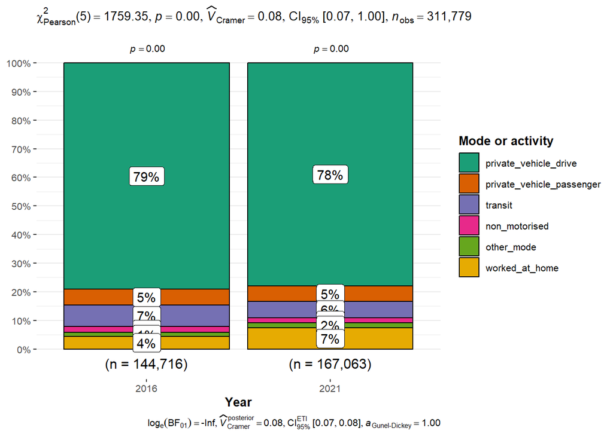

Journey to work mode/activity shares, persons with a usual residence inthe Outer-east grouping, 2016 and 2021 censuses; excluding did not go towork, not stated and not applicable

| Year | Drive | Passenger | Transit | Walk/Bike | Other | WFH | Total |
| --- | --- | --- | --- | --- | --- | --- | --- |
| 2016 | 79.1% (114,492) | 5.5% (7,925) | 7.4% (10,780) | 2.2% (3,155) | 1.4% (2,074) | 4.3% (6,290) | 100.0% (144,716) |
| 2021 | 77.9% (130,137) | 5.5% (9,137) | 5.8% (9,682) | 1.6% (2,711) | 1.8% (2,961) | 7.4% (12,435) | 100.0% (167,063) |

A Pearson’s chi-squared test indicated that the relationship between census and JTW activity/mode was significant $\chi^2(5, N = 311779) = 1759.35$, $p < .001$.

The number of people who drove a private vehicle increased (+15,645, or by +14%), but the drive mode share dropped (-1.2%).

The number of people who worked from home increased by 6,145(98%). WFH share also increased by 3.1%.

The number of people who were a passenger in a private vehicle increased by 1,212(15%), but passenger mode share remained steady (0.0% change).

The number of people who used non-motorised modes fell by -444(-14%). The non-motorised mode share also dropped (-0.6%).

The number of people who used transit dropped slightly (-1,098, -10%). Transit mode share also dropped (-1.7%). The following summarizes the mode split amongst those who used transit:

Outer-east grouping, journey to work mode share by train, bus and ferry, 2021 and 2016 censuses

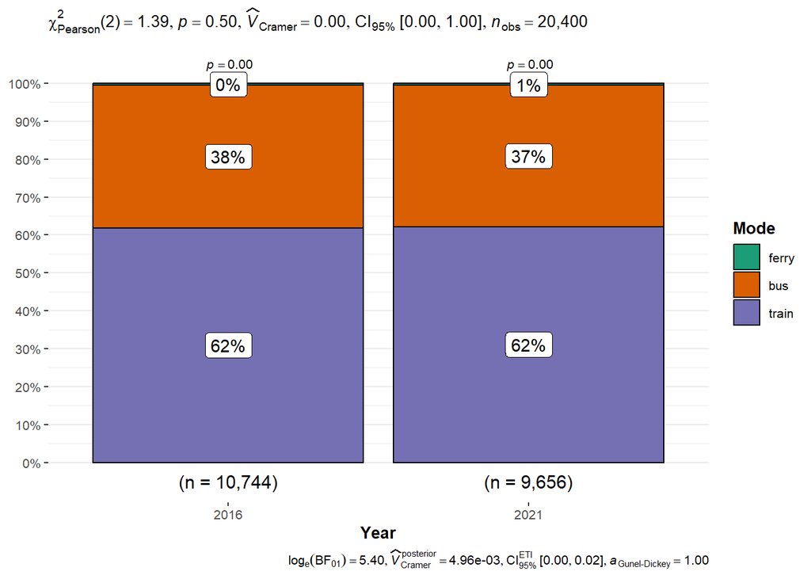

Journey to work mode shares, persons with a usual residence in theOuter-east grouping, 2016 and 2021 censuses

| Year | train | bus | ferry | tram | Total |
| --- | --- | --- | --- | --- | --- |
| 2016 | 61.7% (6,650) | 37.5% (4,046) | 0.4% (48) | 0.3% (36) | 100.0% (10,780) |
| 2021 | 62.0% (6,007) | 37.1% (3,596) | 0.5% (53) | 0.3% (26) | 100.0% (9,682) |

Journey to work mode shares, persons with a usual residence in theOuter-east grouping, 2016 and 2021 censuses

| Year | train | bus | ferry | tram | private_vehicle_drive | private_vehicle_passenger | non_motorised | other_mode | worked_at_home | Total |
| --- | --- | --- | --- | --- | --- | --- | --- | --- | --- | --- |
| 2016 | 4.6% (6,650) | 2.8% (4,046) | 0.0% (48) | 0.0% (36) | 79.1% (114,492) | 5.5% (7,925) | 2.2% (3,155) | 1.4% (2,074) | 4.3% (6,290) | 100.0% (144,716) |
| 2021 | 3.6% (6,007) | 2.2% (3,596) | 0.0% (53) | 0.0% (26) | 77.9% (130,137) | 5.5% (9,137) | 1.6% (2,711) | 1.8% (2,961) | 7.4% (12,435) | 100.0% (167,063) |

A Pearson’s chi-squared test indicated that the relationship between census and the shares of train, bus and ferry ridership was not significant $\chi^2(2, N = 20400) = 1.39$, $p = .499$.

## 3.3 Place of work - CBD

The following shows results for all people whose usual residence is within Greater Perth and whose place of work is within the (central) Perth LGA.

| Year | private_vehicle_drive | private_vehicle_passenger | transit | non_motorised | other_mode | worked_at_home | did_not_go_to_work | not_stated | not_applicable | Total |
| --- | --- | --- | --- | --- | --- | --- | --- | --- | --- | --- |
| 2016 | 36.1% (45,391) | 4.7% (5,945) | 42.3% (53,182) | 5.7% (7,130) | 0.8% (955) | 1.1% (1,360) | 8.4% (10,546) | 0.9% (1,125) | 0.0% (0) | 100.0% (125,634) |
| 2021 | 37.0% (61,429) | 4.7% (7,737) | 31.8% (52,899) | 4.1% (6,741) | 1.0% (1,596) | 10.7% (17,781) | 10.5% (17,462) | 0.3% (576) | 0.0% (0) | 100.0% (166,221) |

Place of work in the (central) Perth LGA and usual residence in Greater Perth, journey to work mode share, 2021 and 2016 censuses

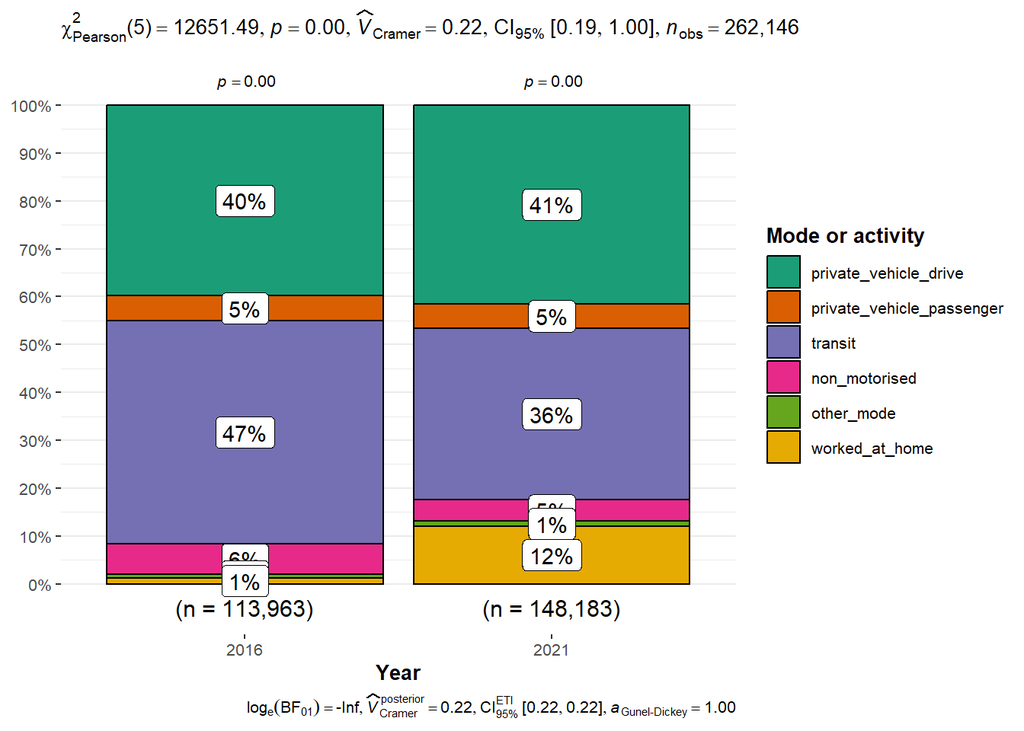

Journey to work mode/activity shares, persons with a usual residence inGreater Perth and place of work in the (central) Perth LGA, 2016 and2021 censuses; excluding did not go to work, not stated and notapplicable

| Year | Drive | Passenger | Transit | Walk/Bike | Other | WFH | Total |
| --- | --- | --- | --- | --- | --- | --- | --- |
| 2016 | 39.8% (45,391) | 5.2% (5,945) | 46.7% (53,182) | 6.3% (7,130) | 0.8% (955) | 1.2% (1,360) | 100.0% (113,963) |
| 2021 | 41.5% (61,429) | 5.2% (7,737) | 35.7% (52,899) | 4.5% (6,741) | 1.1% (1,596) | 12.0% (17,781) | 100.0% (148,183) |

A Pearson’s chi-squared test indicated that the relationship between census and JTW activity/mode was significant $\chi^2(5, N = 262146) = 12651.49$, $p < .001$.

The number of people whose place of work is in the (central) Perth LGA, but who worked from home on the day of the census increased by 16,421(1 207%). The WFH share increased by 10.8%.

The number of people who drove a private vehicle increased by 16,038(+35%). Drive mode share also increased (+1.6%).

The number of people who were a passenger in a private vehicle increased by 1,792(30%), but the passenger mode share did not change.

The number of people who used non-motorised modes did not change by much (-389,-5%). Non-motorised mode share also dropped by a small amount (-1.7%).

Similarly, he number of people who used transit dropped slightly (-283, -1%). However, transit share dropped by a relatively large amount (-11.0%). The following shows the changes in train, bus and ferry ridership:

Place of work in (central) Perth LGA and usual residence in Greater Perth, journey to work mode share by train, bus and ferry, 2021 and 2016 censuses

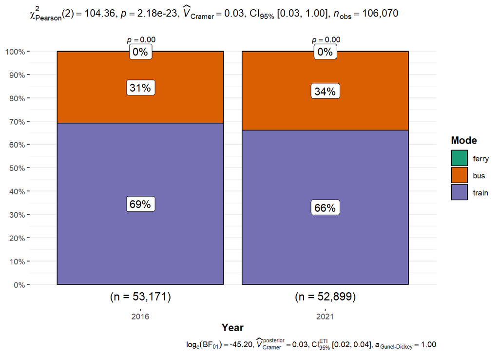

Journey to work shares for each transit mode, persons with a usualresidence in Greater Perth and place of work in the (central) Perth LGA,2016 and 2021 censuses

| Year | train | bus | ferry | tram | Total |
| --- | --- | --- | --- | --- | --- |
| 2016 | 69.1% (36,750) | 30.8% (16,358) | 0.1% (63) | 0.0% (11) | 100.0% (53,182) |
| 2021 | 66.2% (35,012) | 33.7% (17,825) | 0.1% (62) | 0.0% (0) | 100.0% (52,899) |

Journey to work mode shares for transit, persons with a usual residencein Greater Perth and place of work in the (central) Perth LGA, 2016 and2021 censuses

| Year | train | bus | ferry | tram | private_vehicle_drive | private_vehicle_passenger | non_motorised | other_mode | worked_at_home | Total |
| --- | --- | --- | --- | --- | --- | --- | --- | --- | --- | --- |
| 2016 | 32.2% (36,750) | 14.4% (16,358) | 0.1% (63) | 0.0% (11) | 39.8% (45,391) | 5.2% (5,945) | 6.3% (7,130) | 0.8% (955) | 1.2% (1,360) | 100.0% (113,963) |
| 2021 | 23.6% (35,012) | 12.0% (17,825) | 0.0% (62) | 0.0% (0) | 41.5% (61,429) | 5.2% (7,737) | 4.5% (6,741) | 1.1% (1,596) | 12.0% (17,781) | 100.0% (148,183) |

A Pearson’s chi-squared test indicated that the relationship between census and the shares of train, bus and ferry ridership was significant $\chi^2(2, N = 106070) = 104.36$, $p < .001$.

The number of people who used the train fell by 1,738(5%). Train ridership as a share of transit ridership also fell (by 2.9% to 66.2%). The overall train mode share likewise dropped by 8.6% to 23.6%.

Perhaps unexpectedly, bus ridership actually rose by (1,467, 9%) for those whose place of work was within the (central) Perth LGA. Bus ridership also rose as a share of transit ridership by 2.9% to 33.7%. However, the overall bus mode share fell 2.3% to 12.0%.

THe next sections examine the changes for people whose place of work was within the (central) Perth LGA in more detail, looking at those who usually lived in the Heritage, North-south and Outer-east groupings in turn.

### 3.3.1 Place of Work:City of Perth; usual residence: Heritage grouping

The following shows results for all people whose usual residence is within the Heritage grouping of LGAs and whose place of work is within the (central) Perth LGA.

| Year | private_vehicle_drive | private_vehicle_passenger | transit | non_motorised | other_mode | worked_at_home | did_not_go_to_work | not_stated | not_applicable | Total |
| --- | --- | --- | --- | --- | --- | --- | --- | --- | --- | --- |
| 2016 | 33.5% (16,776) | 5.2% (2,606) | 39.8% (19,913) | 10.7% (5,348) | 0.8% (381) | 1.4% (693) | 7.7% (3,863) | 0.9% (445) | 0.0% (0) | 100.0% (50,025) |
| 2021 | 34.4% (22,912) | 5.7% (3,769) | 31.0% (20,637) | 8.3% (5,541) | 0.9% (609) | 9.8% (6,519) | 9.6% (6,431) | 0.4% (237) | 0.0% (0) | 100.0% (66,655) |

Heritage grouping, central Perth place of work, journey to work mode share, 2021 and 2016 censuses

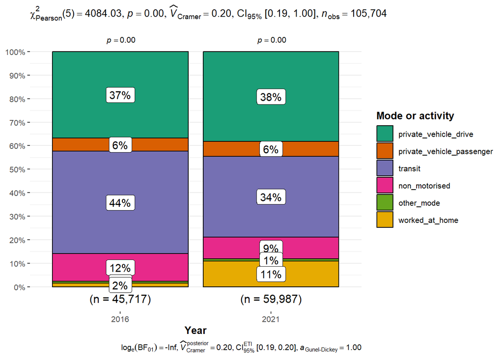

Journey to work mode/activity shares, persons with a usual residence inthe Heritage grouping and place of work in central Perth, 2016 and 2021censuses; excluding did not go to work, not stated and not applicable

| Year | Drive | Passenger | Transit | Walk/Bike | Other | WFH | Total |
| --- | --- | --- | --- | --- | --- | --- | --- |
| 2016 | 36.7% (16,776) | 5.7% (2,606) | 43.6% (19,913) | 11.7% (5,348) | 0.8% (381) | 1.5% (693) | 100.0% (45,717) |
| 2021 | 38.2% (22,912) | 6.3% (3,769) | 34.4% (20,637) | 9.2% (5,541) | 1.0% (609) | 10.9% (6,519) | 100.0% (59,987) |

A Pearson’s chi-squared test indicated that the relationship between census and JTW activity/mode was significant $\chi^2(5, N = 105704) = 4084.03$, $p < .001$.

The number of people who drove a private vehicle increased (+6,136, or by +37%). The drive mode share also increased (+1.5%).

The number of people who worked from home increased by 5,826(+841%). The WFH share increased by 9.4%.

The number of people who were a passenger in a private vehicle increased by 1,163(45%). Passenger mode share also increased (+0.6%).

The number of people who used non-motorised modes increased by 193(4%), but the non-motorised mode share dropped (-2.5%). Similarly, the number of people who used transit increased by a relatively small amount 724(4%), while the overall mode share decreased . However, in the case of transit the mode share change was -9.2%. The following summarizes the mode split amongst those who used transit:

People with a usual residence in the Heritage grouping and a place of work in central Perth, journey to work mode share by train, bus and ferry, 2021 and 2016 censuses

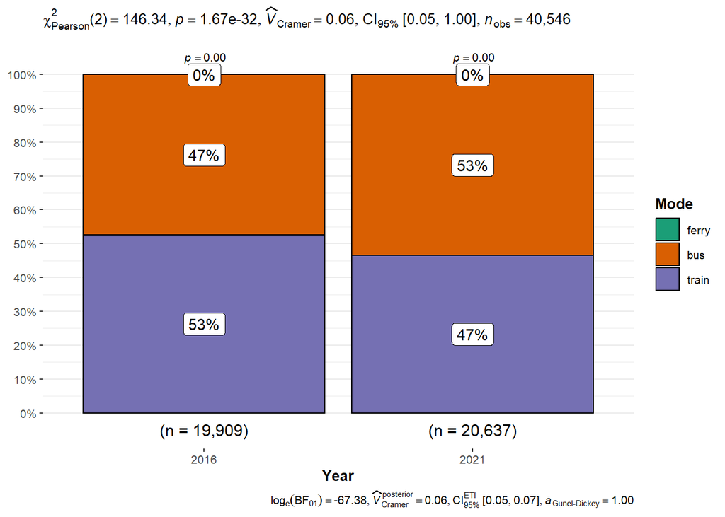

People with a usual residence in the Heritage grouping and a place ofwork in central Perth, journey to work mode share by train, bus andferry, 2021 and 2016 censuses

| Year | train | bus | ferry | tram | Total |
| --- | --- | --- | --- | --- | --- |
| 2016 | 52.6% (10,468) | 47.3% (9,428) | 0.1% (13) | 0.0% (4) | 100.0% (19,913) |
| 2021 | 46.6% (9,611) | 53.4% (11,012) | 0.1% (14) | 0.0% (0) | 100.0% (20,637) |

People with a usual residence in the Heritage grouping and a place ofwork in central Perth, journey to work overall mode share for train, busand ferry, 2021 and 2016 censuses

| Year | train | bus | ferry | tram | private_vehicle_drive | private_vehicle_passenger | non_motorised | other_mode | worked_at_home | Total |
| --- | --- | --- | --- | --- | --- | --- | --- | --- | --- | --- |
| 2016 | 22.9% (10,468) | 20.6% (9,428) | 0.0% (13) | 0.0% (4) | 36.7% (16,776) | 5.7% (2,606) | 11.7% (5,348) | 0.8% (381) | 1.5% (693) | 100.0% (45,717) |
| 2021 | 16.0% (9,611) | 18.4% (11,012) | 0.0% (14) | 0.0% (0) | 38.2% (22,912) | 6.3% (3,769) | 9.2% (5,541) | 1.0% (609) | 10.9% (6,519) | 100.0% (59,987) |

A Pearson’s chi-squared test indicated that the relationship between census and the shares of train, bus and ferry ridership was significant $\chi^2(2, N = 40546) = 146.34$, $p < .001$.

The number of people who used the train fell by 857(8%). Train ridership as a share of transit ridership also decreased (by 6.0% to 46.6%), while the overall train mode share dropped by 6.9% to 16.0%.

Bus ridership actually increased (by1,584, 17%) for those who lived in the Hertigate grouping of LGAs and had a place of work in central Perth. Bus ridership rose as a share of transit ridership by 6.0% to 53.4%, but the overall bus mode share fell by 2.3% to 18.4%.

### 3.3.2 Place of Work: City of Perth; usual residence: North-south grouping

The following shows results for all people whose usual residence is within the North-south grouping of LGAs and whose place of work is within the (central) Perth LGA.

| Year | private_vehicle_drive | private_vehicle_passenger | transit | non_motorised | other_mode | worked_at_home | did_not_go_to_work | not_stated | not_applicable | Total |
| --- | --- | --- | --- | --- | --- | --- | --- | --- | --- | --- |
| 2016 | 37.0% (23,006) | 4.5% (2,784) | 44.7% (27,823) | 2.6% (1,638) | 0.7% (449) | 0.9% (552) | 8.7% (5,415) | 0.9% (542) | 0.0% (0) | 100.0% (62,209) |
| 2021 | 37.7% (30,835) | 4.1% (3,335) | 33.4% (27,307) | 1.4% (1,132) | 0.9% (773) | 11.4% (9,325) | 10.8% (8,850) | 0.3% (267) | 0.0% (0) | 100.0% (81,824) |

North-south grouping, central Perth place of work, journey to work mode share, 2021 and 2016 censuses

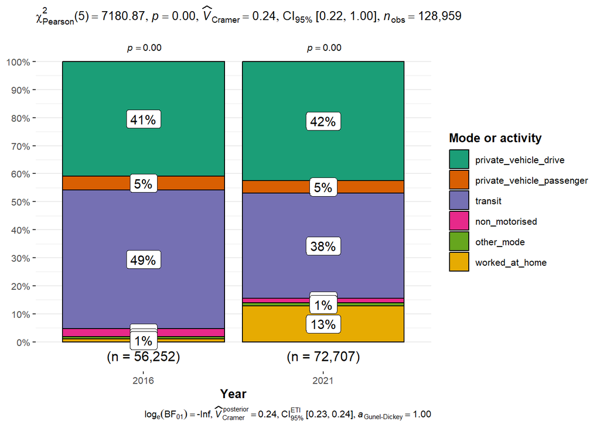

Journey to work mode/activity shares, persons with a usual residence inthe North-south grouping of LGAs and a place of work in central Perth,2016 and 2021 censuses; excluding did not go to work, not stated and notapplicable

| Year | Drive | Passenger | Transit | Walk/Bike | Other | WFH | Total |
| --- | --- | --- | --- | --- | --- | --- | --- |
| 2016 | 40.9% (23,006) | 4.9% (2,784) | 49.5% (27,823) | 2.9% (1,638) | 0.8% (449) | 1.0% (552) | 100.0% (56,252) |
| 2021 | 42.4% (30,835) | 4.6% (3,335) | 37.6% (27,307) | 1.6% (1,132) | 1.1% (773) | 12.8% (9,325) | 100.0% (72,707) |

A Pearson’s chi-squared test indicated that the relationship between census and JTW activity/mode was significant $\chi^2(5, N = 128959) = 7180.87$, $p < .001$.

The largest increase was in the amount of work from home. This increased by 8,773 to 9,325, which is 16.9 times larger than the number of people working from home in 2016. The WFH share also increased by a relatively large amount, rising from 1% to 12.8%.

The number of people who drove a private vehicle increased by 7,829 (+34%). Drive mode share also increased (by 1.5%).

The number of people who were a passenger in a private vehicle increased slightly (+551, +20%). However, passenger mode share dropped by -0.4%.

The number of people who used non-motorised modes shifted by -506(-31%), with non-motorised mode share changing by -1.4%.

The number of people who used transit changed by -516(-2%), with transit mode share changing by -11.9%. The following summarizes the mode split amongst those who used transit:

North-south grouping, central Perth place of work, journey to work share for transit modes, 2021 and 2016 censuses

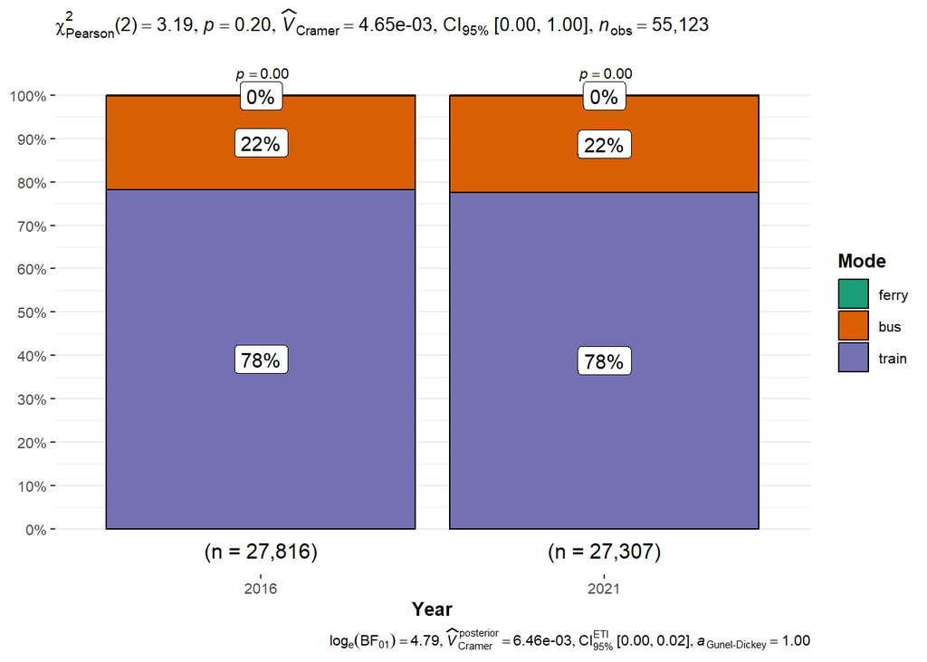

North-south grouping, central Perth place of work, journey to work sharefor transit modes, 2021 and 2016 censuses

| Year | train | bus | ferry | tram | Total |
| --- | --- | --- | --- | --- | --- |
| 2016 | 78.2% (21,765) | 21.6% (6,005) | 0.2% (46) | 0.0% (7) | 100.0% (27,823) |
| 2021 | 77.6% (21,195) | 22.2% (6,067) | 0.2% (45) | 0.0% (0) | 100.0% (27,307) |

North-south grouping, central Perth place of work, journey to work sharefor transit modes, 2021 and 2016 censuses

| Year | train | bus | ferry | tram | private_vehicle_drive | private_vehicle_passenger | non_motorised | other_mode | worked_at_home | Total |
| --- | --- | --- | --- | --- | --- | --- | --- | --- | --- | --- |
| 2016 | 38.7% (21,765) | 10.7% (6,005) | 0.1% (46) | 0.0% (7) | 40.9% (23,006) | 4.9% (2,784) | 2.9% (1,638) | 0.8% (449) | 1.0% (552) | 100.0% (56,252) |
| 2021 | 29.2% (21,195) | 8.3% (6,067) | 0.1% (45) | 0.0% (0) | 42.4% (30,835) | 4.6% (3,335) | 1.6% (1,132) | 1.1% (773) | 12.8% (9,325) | 100.0% (72,707) |

The number of people who used the train fell by 570(3%). Train ridership as a share of transit ridership also fell by 0.6% to 77.6%. Overall, train mode share dropped by 9.5% to 29.2%.

Bus ridership increased by a relatively small amount (62, 1%), and bus ridership also rose as a share of transit ridership (+0.6% to 22.2%). However, overall bus mode share fell by 2.3% to 8.3%.

### 3.3.3 Place of Work: City of Perth; usual residence: Outer-east grouping

The following shows results for all people whose usual residence is within the Outer-east grouping of LGAs and whose place of work is within the (central) Perth LGA.

| Year | private_vehicle_drive | private_vehicle_passenger | transit | non_motorised | other_mode | worked_at_home | did_not_go_to_work | not_stated | not_applicable | Total |
| --- | --- | --- | --- | --- | --- | --- | --- | --- | --- | --- |
| 2016 | 41.9% (5,609) | 4.1% (555) | 40.6% (5,446) | 1.1% (144) | 0.9% (125) | 0.9% (115) | 9.5% (1,268) | 1.0% (138) | 0.0% (0) | 100.0% (13,400) |
| 2021 | 43.3% (7,682) | 3.6% (633) | 27.9% (4,955) | 0.4% (68) | 1.2% (214) | 10.9% (1,937) | 12.3% (2,181) | 0.4% (72) | 0.0% (0) | 100.0% (17,742) |

Outer-east grouping, central Perth place of work, journey to work mode share, 2021 and 2016 censuses

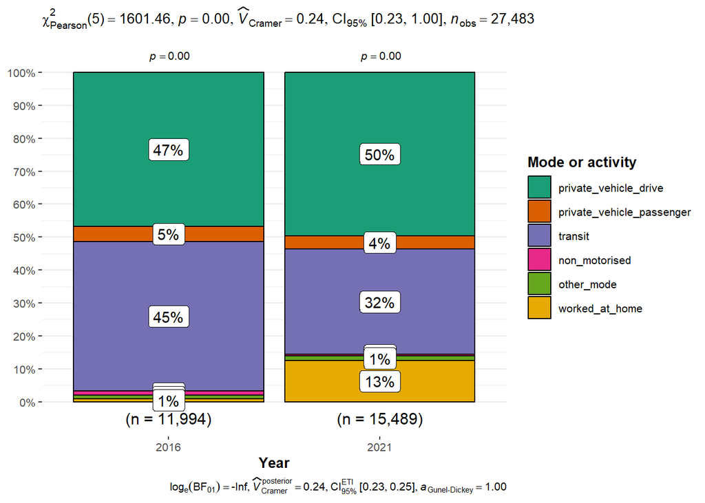

Outer-east grouping, central Perth place of work, journey to work modeshare, 2021 and 2016 censuses

| Year | Drive | Passenger | Transit | Walk/Bike | Other | WFH | Total |
| --- | --- | --- | --- | --- | --- | --- | --- |
| 2016 | 46.8% (5,609) | 4.6% (555) | 45.4% (5,446) | 1.2% (144) | 1.0% (125) | 1.0% (115) | 100.0% (11,994) |
| 2021 | 49.6% (7,682) | 4.1% (633) | 32.0% (4,955) | 0.4% (68) | 1.4% (214) | 12.5% (1,937) | 100.0% (15,489) |

A Pearson’s chi-squared test indicated that the relationship between census and JTW activity/mode was significant $\chi^2(5, N = 27483) = 1601.46$, $p < .001$.

The number of people who worked from home changed by 1,822(1 584%), with WFH share changing by 11.5%.

The number of people who drove a private vehicle increased (+2,073, or by +37%), and drive mode share also increased by 2.8%.

The number of people who were a passenger in a private vehicle changed by 78(14%), with passenger mode share changing by -0.5%.

The number of people who used non-motorised modes shifted by -76(-53%), with non-motorised mode share changing by -0.8%.

The number of people who used transit changed by -491(-9%), with transit mode share changing by -13.4%. The following summarizes the mode split amongst those who used transit:

Outer-east grouping, central Perth place of work, journey to work mode share, 2021 and 2016 censuses

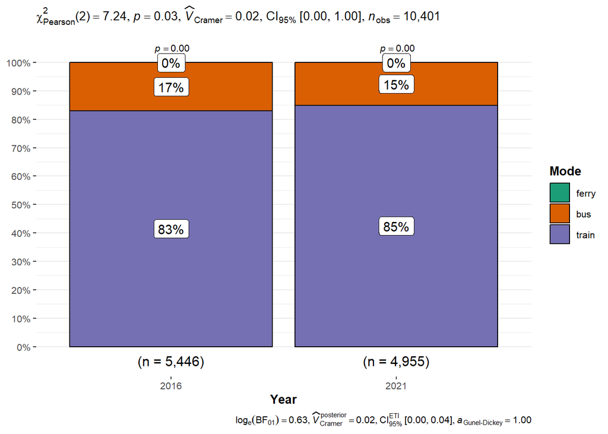

Outer-east grouping, central Perth place of work, journey to work sharefor each transit mode, 2021 and 2016 censuses

| Year | train | bus | ferry | tram | Total |
| --- | --- | --- | --- | --- | --- |
| 2016 | 82.9% (4,517) | 17.0% (925) | 0.1% (4) | 0.0% (0) | 100.0% (5,446) |
| 2021 | 84.9% (4,206) | 15.1% (746) | 0.1% (3) | 0.0% (0) | 100.0% (4,955) |

Outer-east grouping, central Perth place of work, journey to work modeshare, 2021 and 2016 censuses

| Year | train | bus | ferry | tram | private_vehicle_drive | private_vehicle_passenger | non_motorised | other_mode | worked_at_home | Total |
| --- | --- | --- | --- | --- | --- | --- | --- | --- | --- | --- |
| 2016 | 37.7% (4,517) | 7.7% (925) | 0.0% (4) | 0.0% (0) | 46.8% (5,609) | 4.6% (555) | 1.2% (144) | 1.0% (125) | 1.0% (115) | 100.0% (11,994) |
| 2021 | 27.2% (4,206) | 4.8% (746) | 0.0% (3) | 0.0% (0) | 49.6% (7,682) | 4.1% (633) | 0.4% (68) | 1.4% (214) | 12.5% (1,937) | 100.0% (15,489) |

A Pearson’s chi-squared test indicated that the relationship between census and the shares of train, bus and ferry ridership was significant $\chi^2(2, N = 10401) = 7.24$, $p = .027$.

The number of people who used the train fell by 311(7%), but train ridership as a share of transit ridership increased by 1.9% to 84.9%. There was, however, a relatively large fall in overall train mode share, which dropped by 10.5% to 27.2%.

Bus ridership fell by a similarly small amount (-179) but this represents a fall of 19% in bus ridership between 2016 and 2021. Bus ridership fell a share of transit ridership by 1.9% to 15.1%. The overall bus mode share also fell (by 2.9% to 4.8%).

## 3.4 Place of work - Rest of Greater Perth

Next, the results for people whose place of work was within the rest of Greater Perth (not in the (central) City of Perth LGA) are presented. The following shows the aggregate for all people whose usual residence was in Greater Perth:

| Year | private_vehicle_drive | private_vehicle_passenger | transit | non_motorised | other_mode | worked_at_home | did_not_go_to_work | not_stated | not_applicable | Total |
| --- | --- | --- | --- | --- | --- | --- | --- | --- | --- | --- |
| 2016 | 73.0% (522,747) | 4.6% (33,263) | 4.3% (31,131) | 2.5% (18,248) | 0.6% (4,282) | 4.6% (33,140) | 9.4% (67,372) | 0.8% (6,013) | 0.0% (0) | 100.0% (716,196) |
| 2021 | 71.4% (567,381) | 4.8% (38,035) | 3.5% (27,712) | 1.7% (13,831) | 0.5% (4,281) | 7.0% (55,409) | 10.8% (85,483) | 0.4% (2,820) | 0.0% (0) | 100.0% (794,952) |

Place of work in the rest of Greater Perth (not the City of Perth) and usual residence in Greater Perth, journey to work mode share, 2021 and 2016 censuses

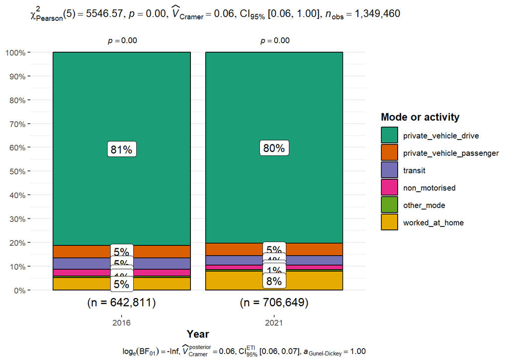

Place of work in the rest of Greater Perth (not the City of Perth) andusual residence in Greater Perth, journey to work mode share, 2021 and2016 censuses

| Year | Drive | Passenger | Transit | Walk/Bike | Other | WFH | Total |
| --- | --- | --- | --- | --- | --- | --- | --- |
| 2016 | 81.3% (522,747) | 5.2% (33,263) | 4.8% (31,131) | 2.8% (18,248) | 0.7% (4,282) | 5.2% (33,140) | 100.0% (642,811) |
| 2021 | 80.3% (567,381) | 5.4% (38,035) | 3.9% (27,712) | 2.0% (13,831) | 0.6% (4,281) | 7.8% (55,409) | 100.0% (706,649) |

A Pearson’s chi-squared test indicated that the relationship between census and JTW activity/mode was significant $\chi^2(5, N = 1349460) = 5546.57$, $p < .001$.

The number of people who drove a private vehicle increased by 44,634 (+9%). However, overall drive mode share decreased (-1.0%).

The second largest change was in the amount of work from home, which increased by 22,269 to 55,409, which is 1.7) times larger than the number of people working from home in 2016. The WFH share also increased, rising from 5% to 7.8%.

Transit ridership dropped (-3,419, -11%), as did the overall transit mode share (-0.9%). The following summarizes the mode split amongst those who used transit:

Place of work in the rest of Greater Perth (not the City of Perth) and usual residence in Greater Perth, journey to work share for transit modes, 2021 and 2016 censuses

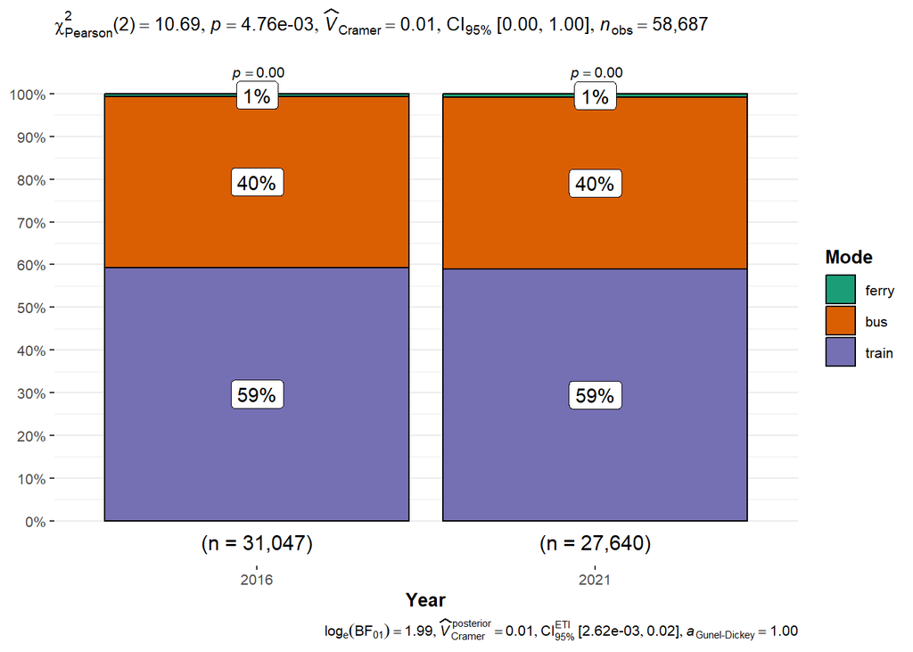

Place of work in the rest of Greater Perth (not the City of Perth) andusual residence in Greater Perth, journey to work shares for transitmodes, 2021 and 2016 censuses

| Year | train | bus | ferry | tram | Total |
| --- | --- | --- | --- | --- | --- |
| 2016 | 59.2% (18,424) | 40.0% (12,442) | 0.6% (181) | 0.3% (84) | 100.0% (31,131) |
| 2021 | 58.8% (16,305) | 40.1% (11,113) | 0.8% (222) | 0.3% (72) | 100.0% (27,712) |

Place of work in the rest of Greater Perth (not the City of Perth) andusual residence in Greater Perth, journey to work mode share, 2021 and2016 censuses

| Year | train | bus | ferry | tram | private_vehicle_drive | private_vehicle_passenger | non_motorised | other_mode | worked_at_home | Total |
| --- | --- | --- | --- | --- | --- | --- | --- | --- | --- | --- |
| 2016 | 2.9% (18,424) | 1.9% (12,442) | 0.0% (181) | 0.0% (84) | 81.3% (522,747) | 5.2% (33,263) | 2.8% (18,248) | 0.7% (4,282) | 5.2% (33,140) | 100.0% (642,811) |
| 2021 | 2.3% (16,305) | 1.6% (11,113) | 0.0% (222) | 0.0% (72) | 80.3% (567,381) | 5.4% (38,035) | 2.0% (13,831) | 0.6% (4,281) | 7.8% (55,409) | 100.0% (706,649) |

A Pearson’s chi-squared test indicated that the relationship between census and the shares of train, bus and ferry ridership was significant $\chi^2(2, N = 58687) = 10.69$, $p = .005$.

Bus ridership fell by 1,329 (-11%). Bus ridership rose as a share of transit ridership by a relatively small amount (0.1% to 40.1%). There was also a relatively small fall in overall bus mode share of 0.4% to 1.6%.

Non-motorised mode usage also decreased (-4,417, -24%), but the change in overall non-motorised mode share was only 0.9%.

### 3.4.1 Place of work: Rest of Greater Perth; Usual residence: Heritage grouping

The following shows results for all people whose usual residence is within the Heritage grouping of LGAs and whose place of work is in Greater Perth, but not within the (central) Perth LGA.

| Year | private_vehicle_drive | private_vehicle_passenger | transit | non_motorised | other_mode | worked_at_home | did_not_go_to_work | not_stated | not_applicable | Total |
| --- | --- | --- | --- | --- | --- | --- | --- | --- | --- | --- |
| 2016 | 70.4% (136,864) | 4.6% (8,879) | 5.8% (11,369) | 4.2% (8,132) | 0.6% (1,100) | 4.8% (9,350) | 8.9% (17,333) | 0.8% (1,520) | 0.0% (0) | 100.0% (194,547) |
| 2021 | 69.1% (145,893) | 4.9% (10,298) | 4.9% (10,356) | 2.7% (5,806) | 0.5% (1,093) | 7.4% (15,675) | 10.1% (21,403) | 0.3% (723) | 0.0% (0) | 100.0% (211,247) |

Heritage grouping residents whose place of work is in Greater Perth but not within the (central) Perth LGA, journey to work mode share, 2021 and 2016 censuses

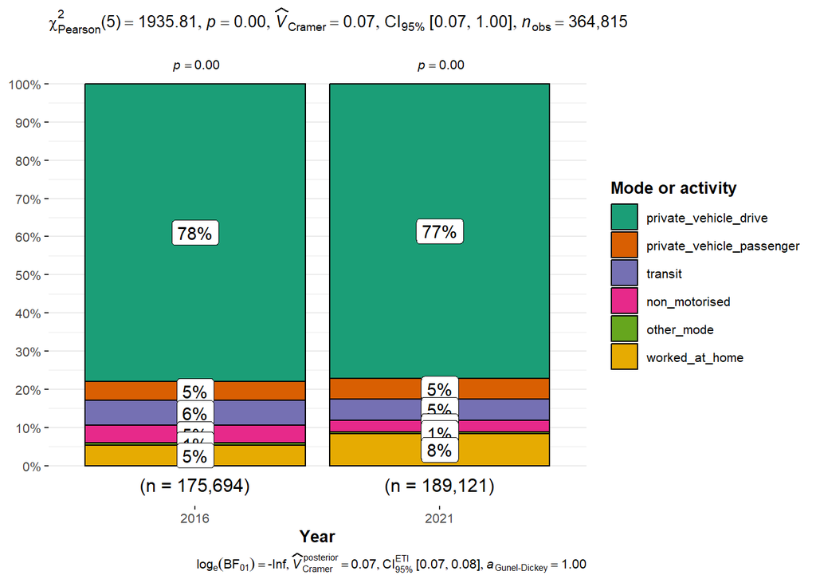

Heritage grouping residents whose place of work is in Greater Perth butnot within the (central) Perth LGA, journey to work mode share, 2021 and2016 censuses

| Year | Drive | Passenger | Transit | Walk/Bike | Other | WFH | Total |
| --- | --- | --- | --- | --- | --- | --- | --- |
| 2016 | 77.9% (136,864) | 5.1% (8,879) | 6.5% (11,369) | 4.6% (8,132) | 0.6% (1,100) | 5.3% (9,350) | 100.0% (175,694) |
| 2021 | 77.1% (145,893) | 5.4% (10,298) | 5.5% (10,356) | 3.1% (5,806) | 0.6% (1,093) | 8.3% (15,675) | 100.0% (189,121) |

A Pearson’s chi-squared test indicated that the relationship between census and JTW activity/mode was significant $\chi^2(5, N = 364815) = 1935.81$, $p < .001$.

The number of people who drove a private vehicle increased (+9,029, +7%), but the drive mode share dropped (-0.8%).

The number of people who worked from home increased by 6,325(68%). WFH share increased by 3.0%.

The number of people who were a passenger in a private vehicle increased by 1,419(16%), but passenger mode share increased by only 0.4%.

The number of people who used transit dropped (-1,013, -9%) while transit mode share also fell (-1.0%). The following summarizes the mode split amongst those who used transit:

Heritage grouping residents whose place of work is in Greater Perth but not within the (central) Perth LGA, journey to work mode share, 2021 and 2016 censuses

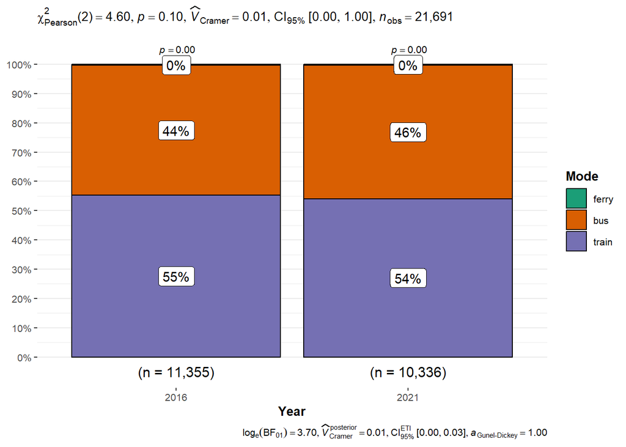

Heritage grouping residents whose place of work is in Greater Perth butnot within the (central) Perth LGA, journey to work mode share, 2021 and2016 censuses

| Year | train | bus | ferry | tram | Total |
| --- | --- | --- | --- | --- | --- |
| 2016 | 55.2% (6,271) | 44.3% (5,042) | 0.4% (42) | 0.1% (14) | 100.0% (11,369) |
| 2021 | 53.9% (5,587) | 45.6% (4,720) | 0.3% (29) | 0.2% (20) | 100.0% (10,356) |

Heritage grouping residents whose place of work is in Greater Perth butnot within the (central) Perth LGA, journey to work mode share, 2021 and2016 censuses

| Year | train | bus | ferry | tram | private_vehicle_drive | private_vehicle_passenger | non_motorised | other_mode | worked_at_home | Total |
| --- | --- | --- | --- | --- | --- | --- | --- | --- | --- | --- |
| 2016 | 3.6% (6,271) | 2.9% (5,042) | 0.0% (42) | 0.0% (14) | 77.9% (136,864) | 5.1% (8,879) | 4.6% (8,132) | 0.6% (1,100) | 5.3% (9,350) | 100.0% (175,694) |
| 2021 | 3.0% (5,587) | 2.5% (4,720) | 0.0% (29) | 0.0% (20) | 77.1% (145,893) | 5.4% (10,298) | 3.1% (5,806) | 0.6% (1,093) | 8.3% (15,675) | 100.0% (189,121) |

Bus ridership fell (-322, -6%), but rose as a share of transit ridership by 1.2% to 45.6%. However, the bus mode share fell by 0.4% to 2.5%.

The number of people who used the train fell by 684(11%). Train ridership as a share of transit ridership also fell by 1.2% to 53.9%, as did overall train mode share dropped (-0.6% to 3.0%).

Notable, the number of people who used non-motorised modes fell by a larger amount (-2,326, -29%) than the falls in train and bus ridership combined. Non-motorised mode share also dropped (-1.6%).

### 3.4.2 Place of work: Rest of Greater Perth; Usual residence: North-south grouping

The following shows results for all people whose usual residence is within the North-south grouping of LGAs and whose place of work is in Greater Perth but not within the (central) Perth LGA.

| Year | private_vehicle_drive | private_vehicle_passenger | transit | non_motorised | other_mode | worked_at_home | did_not_go_to_work | not_stated | not_applicable | Total |
| --- | --- | --- | --- | --- | --- | --- | --- | --- | --- | --- |
| 2016 | 73.4% (285,069) | 4.7% (18,117) | 4.2% (16,402) | 2.0% (7,681) | 0.6% (2,398) | 4.6% (17,880) | 9.7% (37,642) | 0.9% (3,327) | 0.0% (0) | 100.0% (388,516) |
| 2021 | 71.4% (307,807) | 4.8% (20,506) | 3.3% (14,422) | 1.4% (5,980) | 0.5% (2,347) | 7.0% (30,316) | 11.2% (48,100) | 0.3% (1,490) | 0.0% (0) | 100.0% (430,968) |

Residence in North-south grouping whose place of work is in Greater Perth but not within the (central) Perth LGA, journey to work mode share, 2021 and 2016 censuses

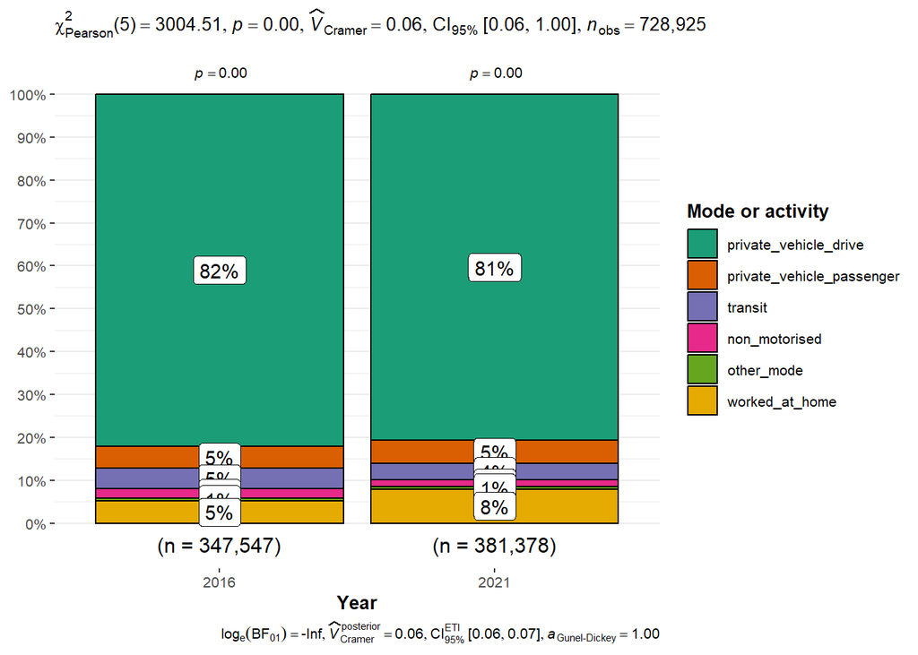

Residence in North-south grouping whose place of work is in GreaterPerth but not within the (central) Perth LGA, journey to work modeshare, 2021 and 2016 censuses

| Year | Drive | Passenger | Transit | Walk/Bike | Other | WFH | Total |
| --- | --- | --- | --- | --- | --- | --- | --- |
| 2016 | 82.0% (285,069) | 5.2% (18,117) | 4.7% (16,402) | 2.2% (7,681) | 0.7% (2,398) | 5.1% (17,880) | 100.0% (347,547) |
| 2021 | 80.7% (307,807) | 5.4% (20,506) | 3.8% (14,422) | 1.6% (5,980) | 0.6% (2,347) | 7.9% (30,316) | 100.0% (381,378) |

A Pearson’s chi-squared test indicated that the relationship between census and JTW activity/mode was significant $\chi^2(5, N = 728925) = 3004.51$, $p < .001$.

The number of people who drove a private vehicle increased (+22,738, +8%), but the drive mode share dropped (-1.3%).

The number of people who worked from home increased by 12,436(70%), with WFH share also increasing by 2.8%.

The number of people who were a passenger in a private vehicle changed by 2,389(13%), with passenger mode share changing by 0.2%.

The number of people who used non-motorised modes droppped (-1,701,-22%), as did non-motorised mode share (-0.6%).

Transit ridership also dropped (-1,980, -12%), as well as transit mode share (-0.9%). The following summarizes the mode split amongst those who used transit:

Residence in North-south grouping whose place of work is in Greater Perth but not within the (central) Perth LGA, journey to work shares for transit modes, 2021 and 2016 censuses

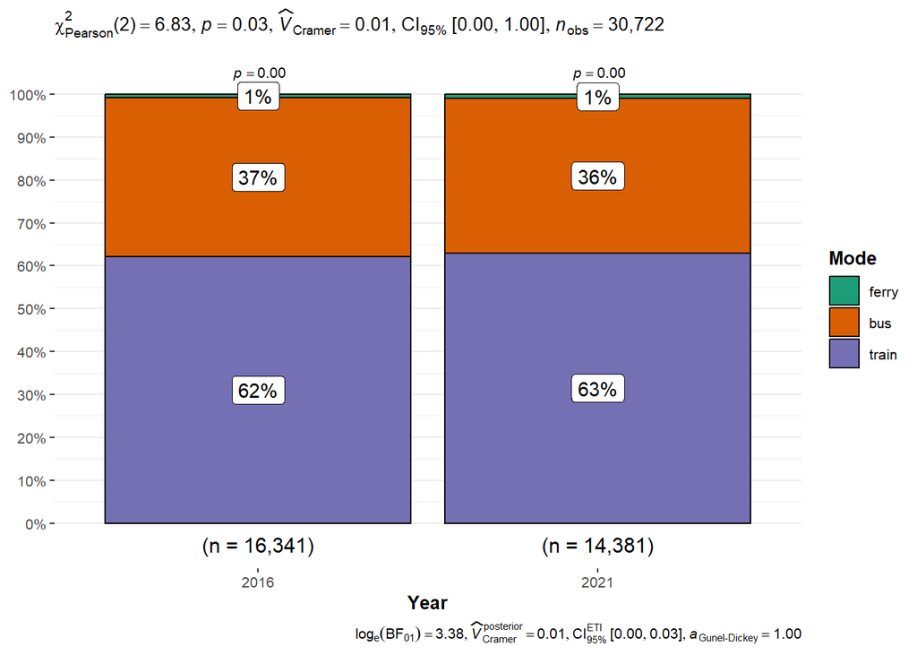

Residence in North-south grouping whose place of work is in GreaterPerth but not within the (central) Perth LGA, journey to work share fortransit modes, 2021 and 2016 censuses

| Year | train | bus | ferry | tram | Total |
| --- | --- | --- | --- | --- | --- |
| 2016 | 61.9% (10,154) | 36.9% (6,058) | 0.8% (129) | 0.4% (61) | 100.0% (16,402) |
| 2021 | 62.8% (9,052) | 36.0% (5,185) | 1.0% (144) | 0.3% (41) | 100.0% (14,422) |

Residence in North-south grouping whose place of work is in GreaterPerth but not within the (central) Perth LGA, journey to work modeshare, 2021 and 2016 censuses

| Year | train | bus | ferry | tram | private_vehicle_drive | private_vehicle_passenger | non_motorised | other_mode | worked_at_home | Total |
| --- | --- | --- | --- | --- | --- | --- | --- | --- | --- | --- |
| 2016 | 2.9% (10,154) | 1.7% (6,058) | 0.0% (129) | 0.0% (61) | 82.0% (285,069) | 5.2% (18,117) | 2.2% (7,681) | 0.7% (2,398) | 5.1% (17,880) | 100.0% (347,547) |
| 2021 | 2.4% (9,052) | 1.4% (5,185) | 0.0% (144) | 0.0% (41) | 80.7% (307,807) | 5.4% (20,506) | 1.6% (5,980) | 0.6% (2,347) | 7.9% (30,316) | 100.0% (381,378) |

A Pearson’s chi-squared test indicated that the relationship between census and the shares of train, bus and ferry ridership was significant $\chi^2(2, N = 30722) = 6.83$, $p = .033$.

Bus ridership fell (-873, -14%) and so did bus ridership as a share of transit ridership (-1.0% to 36.0%). The overall bus mode share fell also, by 0.4% to 1.4%.

The number of people who used the train fell by 1,102 (11%). However, train ridership increased as a share of transit ridership 0.9% to 62.8%, but the overall train mode share dropped by 0.5% to 2.4%.

### 3.4.3 Place of work: Rest of Greater Perth; Usual residence: Outer-east grouping

The following shows results for all people whose usual residence is within the Outer-east grouping of LGAs and whose place of work is in Greater Perth, but not within the (central) Perth LGA.

| Year | private_vehicle_drive | private_vehicle_passenger | transit | non_motorised | other_mode | worked_at_home | did_not_go_to_work | not_stated | not_applicable | Total |
| --- | --- | --- | --- | --- | --- | --- | --- | --- | --- | --- |
| 2016 | 75.7% (100,814) | 4.7% (6,267) | 2.5% (3,360) | 1.8% (2,435) | 0.6% (784) | 4.4% (5,910) | 9.3% (12,397) | 0.9% (1,166) | 0.0% (0) | 100.0% (133,133) |
| 2021 | 74.4% (113,681) | 4.7% (7,231) | 1.9% (2,934) | 1.3% (2,045) | 0.6% (841) | 6.2% (9,418) | 10.5% (15,980) | 0.4% (607) | 0.0% (0) | 100.0% (152,737) |

Residents of the Outer-east grouping of LGAs, whose place of work is in Greater Perth but not within the (central) Perth LGA, journey to work mode share, 2021 and 2016 censuses

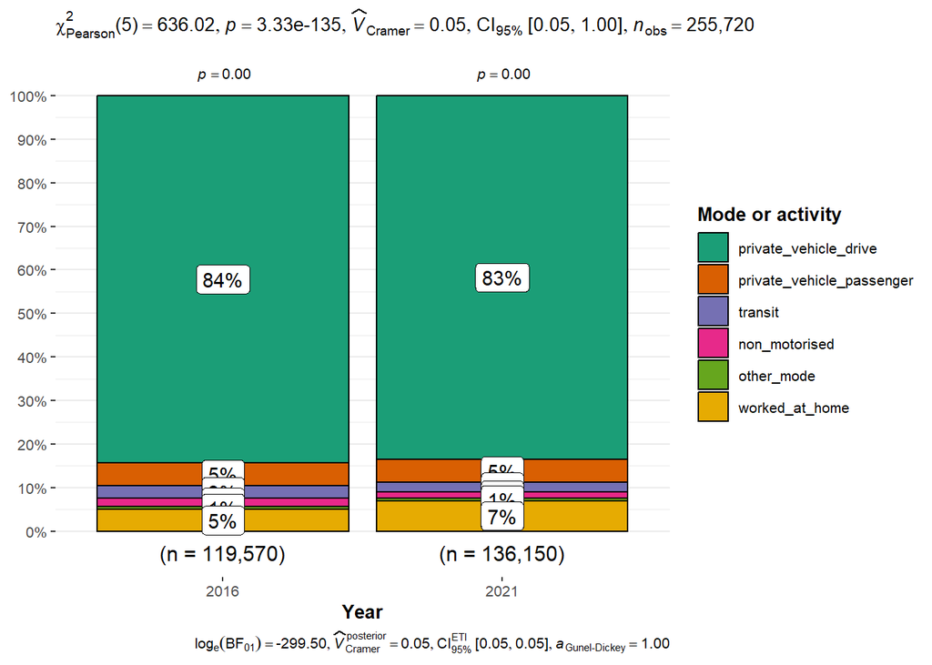

Residents of the Outer-east grouping of LGAs, whose place of work is inGreater Perth but not within the (central) Perth LGA, journey to workmode share, 2021 and 2016 censuses

| Year | Drive | Passenger | Transit | Walk/Bike | Other | WFH | Total |
| --- | --- | --- | --- | --- | --- | --- | --- |
| 2016 | 84.3% (100,814) | 5.2% (6,267) | 2.8% (3,360) | 2.0% (2,435) | 0.7% (784) | 4.9% (5,910) | 100.0% (119,570) |
| 2021 | 83.5% (113,681) | 5.3% (7,231) | 2.2% (2,934) | 1.5% (2,045) | 0.6% (841) | 6.9% (9,418) | 100.0% (136,150) |

A Pearson’s chi-squared test indicated that the relationship between census and JTW activity/mode was significant $\chi^2(5, N = 255720) = 636.02$, $p < .001$.

The number of people who drove a private vehicle increased (+12,867, +13%), but the drive mode share dropped (-0.8%).

The number of people who worked from home increased by 3,508(59%). WFH share also increased (2.0%).

The number of people who were a passenger in a private vehicle increased by 964(15%). There was a relatively small change in passenger mode share (+0.1%).

The number of people who used non-motorised modes fell (-390, -16%). Non-motorised mode share also fell (-0.5%).

The number of people who used transit fell (-426, -13%), as did transit mode share (-0.7%). The following summarizes the mode split amongst those who used transit:

Residents of the Outer-east grouping of LGAs, whose place of work is in Greater Perth but not within the (central) Perth LGA, journey to work mode share, 2021 and 2016 censuses

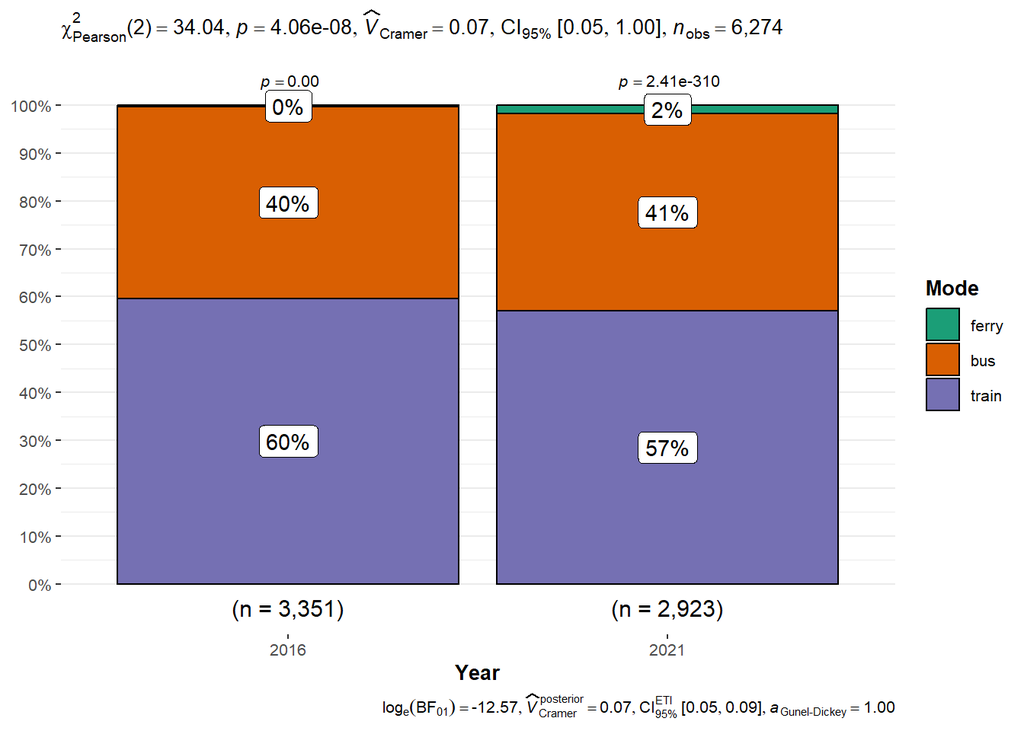

Residents of the Outer-east grouping of LGAs, whose place of work is inGreater Perth but not within the (central) Perth LGA, journey to workshare for transit modes, 2021 and 2016 censuses

| Year | train | bus | ferry | tram | Total |
| --- | --- | --- | --- | --- | --- |
| 2016 | 59.5% (1,999) | 39.9% (1,342) | 0.3% (10) | 0.3% (9) | 100.0% (3,360) |
| 2021 | 56.8% (1,666) | 41.2% (1,208) | 1.7% (49) | 0.4% (11) | 100.0% (2,934) |

Residents of the Outer-east grouping of LGAs, whose place of work is inGreater Perth but not within the (central) Perth LGA, journey to workmode share, 2021 and 2016 censuses

| Year | train | bus | ferry | tram | private_vehicle_drive | private_vehicle_passenger | non_motorised | other_mode | worked_at_home | Total |
| --- | --- | --- | --- | --- | --- | --- | --- | --- | --- | --- |
| 2016 | 1.7% (1,999) | 1.1% (1,342) | 0.0% (10) | 0.0% (9) | 84.3% (100,814) | 5.2% (6,267) | 2.0% (2,435) | 0.7% (784) | 4.9% (5,910) | 100.0% (119,570) |
| 2021 | 1.2% (1,666) | 0.9% (1,208) | 0.0% (49) | 0.0% (11) | 83.5% (113,681) | 5.3% (7,231) | 1.5% (2,045) | 0.6% (841) | 6.9% (9,418) | 100.0% (136,150) |

A Pearson’s chi-squared test indicated that the relationship between census and the shares of train, bus and ferry ridership was significant $\chi^2(2, N = 6274) = 34.04$, $p < .001$.

The number of people who used the train fell by 333 (17%). Train ridership also fell as a share of transit ridership, by 2.7% to 56.8%. Overall train mode share also fell 0.4% to 1.2%.

## 3.5 Place of work - not Greater Perth

The following shows results for all people whose usual residence is within Greater Perth, but whose place of work is somewhere else.

| Year | private_vehicle_drive | private_vehicle_passenger | transit | non_motorised | other_mode | worked_at_home | did_not_go_to_work | not_stated | not_applicable | Total |
| --- | --- | --- | --- | --- | --- | --- | --- | --- | --- | --- |
| 2016 | 51.4% (38,157) | 6.8% (5,016) | 11.9% (8,815) | 2.8% (2,054) | 7.3% (5,408) | 1.0% (726) | 17.2% (12,797) | 1.8% (1,303) | 0.0% (0) | 100.0% (74,276) |
| 2021 | 46.5% (42,382) | 6.5% (5,966) | 9.0% (8,165) | 2.4% (2,231) | 9.2% (8,424) | 4.3% (3,918) | 21.5% (19,608) | 0.5% (437) | 0.0% (0) | 100.0% (91,131) |

Place of work not in Greater Perth and usual residence in Greater Perth, journey to work mode share, 2021 and 2016 censuses

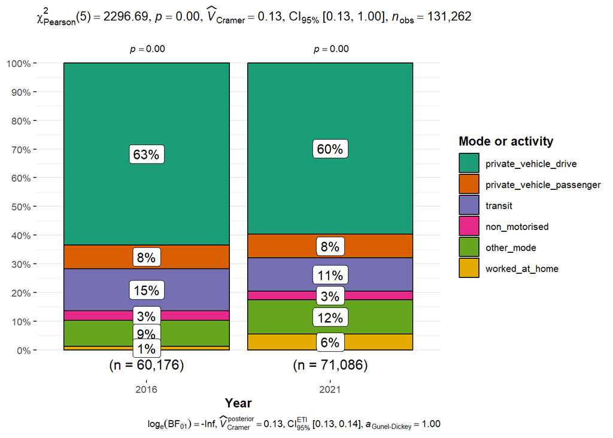

Journey to work mode/activity shares, persons with a usual residence inGreater Perth, 2016 and 2021 censuses; excluding did not go to work, notstated and not applicable

| Year | Drive | Passenger | Transit | Walk/Bike | Other | WFH | Total |
| --- | --- | --- | --- | --- | --- | --- | --- |
| 2016 | 63.4% (38,157) | 8.3% (5,016) | 14.6% (8,815) | 3.4% (2,054) | 9.0% (5,408) | 1.2% (726) | 100.0% (60,176) |
| 2021 | 59.6% (42,382) | 8.4% (5,966) | 11.5% (8,165) | 3.1% (2,231) | 11.9% (8,424) | 5.5% (3,918) | 100.0% (71,086) |

A Pearson’s chi-squared test indicated that the relationship between census and JTW activity/mode was significant $\chi^2(5, N = 131262) = 2296.69$, $p < .001$.

The number of people who drove a private vehicle increased by 4,225 (11%). However, drive mode share dropped (-3.8%).

The number of people who worked from home increased by 3,192(440%), with WFH share also growing by 4.3%.

The number of people who were a passenger in a private vehicle increased by 950(19%), but passenger mode share only increased by a relatively small amount (0.1%).

The use of non-motorised modes also increased, but by only 177 people (+9%). However, non-motorised mode share fell (-0.3%).

The number of people who used transit fell (-650, -7%). Transit mode share also dropped (-3.2%). The following summarizes the mode split amongst those who used transit:

Greater Perth, journey to work mode share by train and bus, 2021 and 2016 censuses

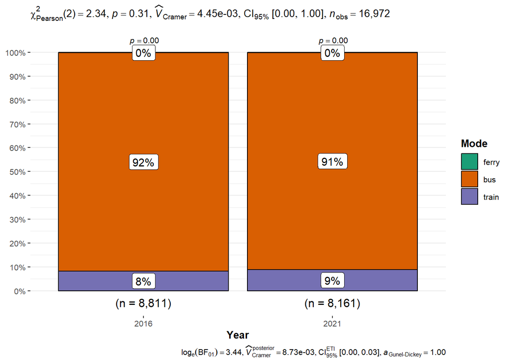

Journey to work mode shares for transit, persons with a usual residencein Greater Perth, 2016 and 2021 censuses; excluding did not go to work,not stated and not applicable

| Year | train | bus | ferry | tram | Total |
| --- | --- | --- | --- | --- | --- |
| 2016 | 8.2% (726) | 91.6% (8,077) | 0.1% (8) | 0.0% (4) | 100.0% (8,815) |
| 2021 | 8.9% (724) | 91.0% (7,428) | 0.1% (9) | 0.0% (4) | 100.0% (8,165) |

Journey to work mode shares, persons with a usual residence in GreaterPerth, 2016 and 2021 censuses; excluding did not go to work, not statedand not applicable

| Year | train | bus | ferry | tram | private_vehicle_drive | private_vehicle_passenger | non_motorised | other_mode | worked_at_home | Total |
| --- | --- | --- | --- | --- | --- | --- | --- | --- | --- | --- |
| 2016 | 1.2% (726) | 13.4% (8,077) | 0.0% (8) | 0.0% (4) | 63.4% (38,157) | 8.3% (5,016) | 3.4% (2,054) | 9.0% (5,408) | 1.2% (726) | 100.0% (60,176) |
| 2021 | 1.0% (724) | 10.4% (7,428) | 0.0% (9) | 0.0% (4) | 59.6% (42,382) | 8.4% (5,966) | 3.1% (2,231) | 11.9% (8,424) | 5.5% (3,918) | 100.0% (71,086) |

A Pearson’s chi-squared test indicated that the relationship between census and the shares of train, bus and ferry ridership was not significant $\chi^2(2, N = 16972) = 2.34$, $p = .311$.

Journey to work mode shares, persons with a usual residence in Greater Perth, 2016 and 2021 censuses; excluding did not go to work, not stated and not applicable

| Year | train | bus | ferry | tram | private_vehicle_drive | private_vehicle_passenger | non_motorised | other_mode | worked_at_home | Total |
| --- | --- | --- | --- | --- | --- | --- | --- | --- | --- | --- |
| 2016 | 1.6% (205) | 13.1% (1,639) | 0.0% (0) | 0.0% (0) | 62.7% (7,868) | 8.2% (1,031) | 4.0% (507) | 8.7% (1,092) | 1.7% (211) | 100.0% (12,553) |
| 2021 | 1.5% (240) | 10.3% (1,624) | 0.0% (3) | 0.0% (0) | 58.3% (9,153) | 8.0% (1,257) | 4.0% (627) | 10.6% (1,669) | 7.2% (1,130) | 100.0% (15,703) |

| Year | private_vehicle_drive | private_vehicle_passenger | transit | non_motorised | other_mode | worked_at_home | did_not_go_to_work | not_stated | not_applicable | Total |
| --- | --- | --- | --- | --- | --- | --- | --- | --- | --- | --- |
| 2016 | 51.3% (22,734) | 6.9% (3,061) | 12.0% (5,324) | 2.8% (1,220) | 7.3% (3,239) | 0.8% (376) | 17.1% (7,594) | 1.8% (789) | 0.0% (0) | 100.0% (44,337) |
| 2021 | 46.8% (24,981) | 6.6% (3,545) | 8.7% (4,638) | 2.2% (1,201) | 9.3% (4,994) | 4.1% (2,187) | 21.7% (11,601) | 0.5% (265) | 0.0% (0) | 100.0% (53,412) |

Residence in North-south grouping whose Place of work not in Greater Perth, journey to work mode share, 2021 and 2016 censuses

[figure not shown]

Journey to work mode/activity shares, persons with a usual residence in Greater Perth, 2016 and 2021 censuses; excluding did not go to work, not stated and not applicable

| Year | private_vehicle_drive | private_vehicle_passenger | transit | non_motorised | other_mode | worked_at_home | Total |
| --- | --- | --- | --- | --- | --- | --- | --- |
| 2016 | 63.2% (22,734) | 8.5% (3,061) | 14.8% (5,324) | 3.4% (1,220) | 9.0% (3,239) | 1.0% (376) | 100.0% (35,954) |
| 2021 | 60.1% (24,981) | 8.5% (3,545) | 11.2% (4,638) | 2.9% (1,201) | 12.0% (4,994) | 5.3% (2,187) | 100.0% (41,546) |

Greater Perth, journey to work mode share by train and bus, 2021 and 2016 censuses

[figure not shown]

Journey to work mode shares for transit, persons with a usual residence in Greater Perth, 2016 and 2021 censuses; excluding did not go to work, not stated and not applicable

| Year | train | bus | ferry | tram | Total |
| --- | --- | --- | --- | --- | --- |
| 2016 | 8.4% (445) | 91.5% (4,872) | 0.1% (3) | 0.1% (4) | 100.0% (5,324) |
| 2021 | 9.1% (421) | 90.8% (4,213) | 0.0% (0) | 0.1% (4) | 100.0% (4,638) |

Journey to work mode shares, persons with a usual residence in Greater Perth, 2016 and 2021 censuses; excluding did not go to work, not stated and not applicable

| Year | train | bus | ferry | tram | private_vehicle_drive | private_vehicle_passenger | non_motorised | other_mode | worked_at_home | Total |
| --- | --- | --- | --- | --- | --- | --- | --- | --- | --- | --- |
| 2016 | 1.2% (445) | 13.6% (4,872) | 0.0% (3) | 0.0% (4) | 63.2% (22,734) | 8.5% (3,061) | 3.4% (1,220) | 9.0% (3,239) | 1.0% (376) | 100.0% (35,954) |
| 2021 | 1.0% (421) | 10.1% (4,213) | 0.0% (0) | 0.0% (4) | 60.1% (24,981) | 8.5% (3,545) | 2.9% (1,201) | 12.0% (4,994) | 5.3% (2,187) | 100.0% (41,546) |

[output not shown]

Outer-east grouping, whose place of work is is not in Greater Perth, journey to work mode share, 2021 and 2016 censuses

[figure not shown]

Journey to work mode/activity shares, persons with a usual residence in Greater Perth, 2016 and 2021 censuses; excluding did not go to work, not stated and not applicable

[output not shown]

Greater Perth, journey to work mode share by train and bus, 2021 and 2016 censuses

[figure not shown]

Journey to work mode shares for transit, persons with a usual residence in Greater Perth, 2016 and 2021 censuses; excluding did not go to work, not stated and not applicable

[output not shown]

Journey to work mode shares, persons with a usual residence in Greater Perth, 2016 and 2021 censuses; excluding did not go to work, not stated and not applicable

[output not shown]

## 3.6 Summary

The following summarises each mode/activity for the 2016 and 2021 censuses by share and the number of people.

| Year | UR | POW | Drive | Passenger | Transit | Walk/Bike | Other | WFH | Total |
| --- | --- | --- | --- | --- | --- | --- | --- | --- | --- |
| 2016 | Greater Perth | All | 73.8% (605,199) | 5.5% (44,875) | 11.6% (94,912) | 3.5% (28,366) | 1.4% (11,265) | 4.3% (35,528) | 100.0% (820,145) |
| 2016 | Heritage | All | 68.5% (162,376) | 5.4% (12,876) | 14.3% (33,884) | 6.1% (14,473) | 1.2% (2,812) | 4.4% (10,512) | 100.0% (236,933) |
| 2016 | North-south | All | 74.9% (332,338) | 5.5% (24,403) | 11.4% (50,374) | 2.5% (11,022) | 1.5% (6,447) | 4.3% (19,159) | 100.0% (443,743) |
| 2016 | Outer-east | All | 79.1% (114,492) | 5.5% (7,925) | 7.4% (10,780) | 2.2% (3,155) | 1.4% (2,074) | 4.3% (6,290) | 100.0% (144,716) |
| 2016 | Greater Perth | City of Perth | 39.8% (45,391) | 5.2% (5,945) | 46.7% (53,182) | 6.3% (7,130) | 0.8% (955) | 1.2% (1,360) | 100.0% (113,963) |
| 2016 | Heritage | City of Perth | 36.7% (16,776) | 5.7% (2,606) | 43.6% (19,913) | 11.7% (5,348) | 0.8% (381) | 1.5% (693) | 100.0% (45,717) |
| 2016 | North-south | City of Perth | 40.9% (23,006) | 4.9% (2,784) | 49.5% (27,823) | 2.9% (1,638) | 0.8% (449) | 1.0% (552) | 100.0% (56,252) |
| 2016 | Outer-east | City of Perth | 46.8% (5,609) | 4.6% (555) | 45.4% (5,446) | 1.2% (144) | 1.0% (125) | 1.0% (115) | 100.0% (11,994) |
| 2016 | Greater Perth | Rest of Greater Perth | 81.3% (522,747) | 5.2% (33,263) | 4.8% (31,131) | 2.8% (18,248) | 0.7% (4,282) | 5.2% (33,140) | 100.0% (642,811) |
| 2016 | Heritage | Rest of Greater Perth | 77.9% (136,864) | 5.1% (8,879) | 6.5% (11,369) | 4.6% (8,132) | 0.6% (1,100) | 5.3% (9,350) | 100.0% (175,694) |
| 2016 | North-south | Rest of Greater Perth | 82.0% (285,069) | 5.2% (18,117) | 4.7% (16,402) | 2.2% (7,681) | 0.7% (2,398) | 5.1% (17,880) | 100.0% (347,547) |
| 2016 | Outer-east | Rest of Greater Perth | 84.3% (100,814) | 5.2% (6,267) | 2.8% (3,360) | 2.0% (2,435) | 0.7% (784) | 4.9% (5,910) | 100.0% (119,570) |
| 2016 | Greater Perth | Other than Greater Perth | 63.4% (38,157) | 8.3% (5,016) | 14.6% (8,815) | 3.4% (2,054) | 9.0% (5,408) | 1.2% (726) | 100.0% (60,176) |

| Year | UR | POW | Drive | Passenger | Transit | Walk/Bike | Other | WFH | Total |
| --- | --- | --- | --- | --- | --- | --- | --- | --- | --- |
| 2021 | Greater Perth | All | 72.0% (670,135) | 5.6% (52,331) | 9.6% (89,541) | 2.5% (23,659) | 1.6% (14,942) | 8.7% (80,658) | 100.0% (931,266) |
| 2021 | Heritage | All | 66.6% (179,016) | 5.9% (15,770) | 12.4% (33,242) | 4.6% (12,460) | 1.4% (3,647) | 9.2% (24,801) | 100.0% (268,936) |
| 2021 | North-south | All | 72.9% (365,130) | 5.5% (27,773) | 9.3% (46,704) | 1.7% (8,725) | 1.7% (8,423) | 8.8% (43,916) | 100.0% (500,671) |
| 2021 | Outer-east | All | 77.9% (130,137) | 5.5% (9,137) | 5.8% (9,682) | 1.6% (2,711) | 1.8% (2,961) | 7.4% (12,435) | 100.0% (167,063) |
| 2021 | Greater Perth | City of Perth | 41.5% (61,429) | 5.2% (7,737) | 35.7% (52,899) | 4.5% (6,741) | 1.1% (1,596) | 12.0% (17,781) | 100.0% (148,183) |
| 2021 | Heritage | City of Perth | 38.2% (22,912) | 6.3% (3,769) | 34.4% (20,637) | 9.2% (5,541) | 1.0% (609) | 10.9% (6,519) | 100.0% (59,987) |
| 2021 | North-south | City of Perth | 42.4% (30,835) | 4.6% (3,335) | 37.6% (27,307) | 1.6% (1,132) | 1.1% (773) | 12.8% (9,325) | 100.0% (72,707) |
| 2021 | Outer-east | City of Perth | 49.6% (7,682) | 4.1% (633) | 32.0% (4,955) | 0.4% (68) | 1.4% (214) | 12.5% (1,937) | 100.0% (15,489) |
| 2021 | Greater Perth | Rest of Greater Perth | 80.3% (567,381) | 5.4% (38,035) | 3.9% (27,712) | 2.0% (13,831) | 0.6% (4,281) | 7.8% (55,409) | 100.0% (706,649) |
| 2021 | Heritage | Rest of Greater Perth | 77.1% (145,893) | 5.4% (10,298) | 5.5% (10,356) | 3.1% (5,806) | 0.6% (1,093) | 8.3% (15,675) | 100.0% (189,121) |
| 2021 | North-south | Rest of Greater Perth | 80.7% (307,807) | 5.4% (20,506) | 3.8% (14,422) | 1.6% (5,980) | 0.6% (2,347) | 7.9% (30,316) | 100.0% (381,378) |
| 2021 | Outer-east | Rest of Greater Perth | 83.5% (113,681) | 5.3% (7,231) | 2.2% (2,934) | 1.5% (2,045) | 0.6% (841) | 6.9% (9,418) | 100.0% (136,150) |
| 2021 | Greater Perth | Other than Greater Perth | 59.6% (42,382) | 8.4% (5,966) | 11.5% (8,165) | 3.1% (2,231) | 11.9% (8,424) | 5.5% (3,918) | 100.0% (71,086) |

The next table also provides a summary, but with the individual transit modes show separately.

Summary of JTW, 2016 and 2021 census, Greater Perth and sub-groupings

| Year | UR | POW | Train | Bus | Ferry | Tram | Non-transit | WFH | Total |
| --- | --- | --- | --- | --- | --- | --- | --- | --- | --- |
| 2016 | Greater Perth | All | 6.9% (56,417) | 4.6% (37,899) | 0.0% (373) | 0.0% (223) | 84.1% (689,705) | 4.3% (35,528) | 100.0% (820,145) |
| 2016 | Heritage | All | 7.3% (17,223) | 7.0% (16,486) | 0.0% (97) | 0.0% (78) | 81.3% (192,537) | 4.4% (10,512) | 100.0% (236,933) |
| 2016 | North-south | All | 7.3% (32,579) | 3.9% (17,456) | 0.0% (219) | 0.0% (120) | 84.3% (374,210) | 4.3% (19,159) | 100.0% (443,743) |
| 2016 | Outer-east | All | 4.6% (6,650) | 2.8% (4,046) | 0.0% (48) | 0.0% (36) | 88.2% (127,646) | 4.3% (6,290) | 100.0% (144,716) |
| 2016 | Greater Perth | City of Perth | 32.2% (36,750) | 14.4% (16,358) | 0.1% (63) | 0.0% (11) | 52.1% (59,421) | 1.2% (1,360) | 100.0% (113,963) |
| 2016 | Heritage | City of Perth | 22.9% (10,468) | 20.6% (9,428) | 0.0% (13) | 0.0% (4) | 54.9% (25,111) | 1.5% (693) | 100.0% (45,717) |
| 2016 | North-south | City of Perth | 38.7% (21,765) | 10.7% (6,005) | 0.1% (46) | 0.0% (7) | 49.6% (27,877) | 1.0% (552) | 100.0% (56,252) |
| 2016 | Outer-east | City of Perth | 37.7% (4,517) | 7.7% (925) | 0.0% (4) | 0.0% (0) | 53.6% (6,433) | 1.0% (115) | 100.0% (11,994) |
| 2016 | Greater Perth | Rest of Greater Perth | 2.9% (18,424) | 1.9% (12,442) | 0.0% (181) | 0.0% (84) | 90.0% (578,540) | 5.2% (33,140) | 100.0% (642,811) |
| 2016 | Heritage | Rest of Greater Perth | 3.6% (6,271) | 2.9% (5,042) | 0.0% (42) | 0.0% (14) | 88.2% (154,975) | 5.3% (9,350) | 100.0% (175,694) |
| 2016 | North-south | Rest of Greater Perth | 2.9% (10,154) | 1.7% (6,058) | 0.0% (129) | 0.0% (61) | 90.1% (313,265) | 5.1% (17,880) | 100.0% (347,547) |
| 2016 | Outer-east | Rest of Greater Perth | 1.7% (1,999) | 1.1% (1,342) | 0.0% (10) | 0.0% (9) | 92.2% (110,300) | 4.9% (5,910) | 100.0% (119,570) |
| 2016 | Greater Perth | Other than Greater Perth | 1.2% (726) | 13.4% (8,077) | 0.0% (8) | 0.0% (4) | 84.1% (50,635) | 1.2% (726) | 100.0% (60,176) |

| Year | UR | POW | Train | Bus | Ferry | Tram | Non-transit | WFH | Total |
| --- | --- | --- | --- | --- | --- | --- | --- | --- | --- |
| 2021 | Greater Perth | All | 5.6% (52,327) | 3.9% (36,687) | 0.0% (395) | 0.0% (132) | 81.7% (761,067) | 8.7% (80,658) | 100.0% (931,266) |
| 2021 | Heritage | All | 5.8% (15,560) | 6.5% (17,557) | 0.0% (91) | 0.0% (34) | 78.4% (210,893) | 9.2% (24,801) | 100.0% (268,936) |
| 2021 | North-south | All | 6.1% (30,790) | 3.1% (15,606) | 0.0% (236) | 0.0% (72) | 81.9% (410,051) | 8.8% (43,916) | 100.0% (500,671) |
| 2021 | Outer-east | All | 3.6% (6,007) | 2.2% (3,596) | 0.0% (53) | 0.0% (26) | 86.8% (144,946) | 7.4% (12,435) | 100.0% (167,063) |
| 2021 | Greater Perth | City of Perth | 23.6% (35,012) | 12.0% (17,825) | 0.0% (62) | 0.0% (0) | 52.3% (77,503) | 12.0% (17,781) | 100.0% (148,183) |
| 2021 | Heritage | City of Perth | 16.0% (9,611) | 18.4% (11,012) | 0.0% (14) | 0.0% (0) | 54.7% (32,831) | 10.9% (6,519) | 100.0% (59,987) |
| 2021 | North-south | City of Perth | 29.2% (21,195) | 8.3% (6,067) | 0.1% (45) | 0.0% (0) | 49.6% (36,075) | 12.8% (9,325) | 100.0% (72,707) |
| 2021 | Outer-east | City of Perth | 27.2% (4,206) | 4.8% (746) | 0.0% (3) | 0.0% (0) | 55.5% (8,597) | 12.5% (1,937) | 100.0% (15,489) |
| 2021 | Greater Perth | Rest of Greater Perth | 2.3% (16,305) | 1.6% (11,113) | 0.0% (222) | 0.0% (72) | 88.2% (623,528) | 7.8% (55,409) | 100.0% (706,649) |
| 2021 | Heritage | Rest of Greater Perth | 3.0% (5,587) | 2.5% (4,720) | 0.0% (29) | 0.0% (20) | 86.2% (163,090) | 8.3% (15,675) | 100.0% (189,121) |
| 2021 | North-south | Rest of Greater Perth | 2.4% (9,052) | 1.4% (5,185) | 0.0% (144) | 0.0% (41) | 88.3% (336,640) | 7.9% (30,316) | 100.0% (381,378) |
| 2021 | Outer-east | Rest of Greater Perth | 1.2% (1,666) | 0.9% (1,208) | 0.0% (49) | 0.0% (11) | 90.9% (123,798) | 6.9% (9,418) | 100.0% (136,150) |
| 2021 | Greater Perth | Other than Greater Perth | 1.0% (724) | 10.4% (7,428) | 0.0% (9) | 0.0% (4) | 83.0% (59,003) | 5.5% (3,918) | 100.0% (71,086) |

# 4.0 Discussion

## 4.1 Changes in population, and employment and/or study

Population summary

| grouping | Population_2016 | Population_2021 |
| --- | --- | --- |
| Heritage | 28.8% (496,976) | 26.3% (534,177) |
| North-south | 59.0% (1,016,890) | 54.4% (1,107,061) |
| Outer-east | 12.2% (210,174) | 19.3% (392,078) |
| Total | 100.0% (1,724,040) | 100.0% (2,033,316) |

Ppopulation engaged in employment and/or study summary

| grouping | Employed_2016 | Employed_2021 |
| --- | --- | --- |
| Heritage | 27.6% (270,945) | 27.3% (300,973) |
| North-south | 54.1% (531,473) | 54.0% (595,359) |
| Outer-east | 18.3% (179,388) | 18.7% (205,793) |
| Total | 100.0% (981,806) | 100.0% (1,102,125) |

## 4.2 Changes in mode share

The following table summarises changes in mode/activity share for each of the combinations of usual residence grouping and place of work.

Change in mode share by place of usual residence and place of work

| UR | POW | Drive | Passenger | Transit | Walk/Bike | Other | WFH |
| --- | --- | --- | --- | --- | --- | --- | --- |
| Greater Perth | All | -1.8% | 0.1% | -2.0% | -0.9% | 0.2% | 4.3% |
| Heritage | All | -2.0% | 0.4% | -1.9% | -1.5% | 0.2% | 4.8% |
| North-south | All | -2.0% | 0.0% | -2.0% | -0.7% | 0.2% | 4.5% |
| Outer-east | All | -1.2% | 0.0% | -1.7% | -0.6% | 0.3% | 3.1% |
| Greater Perth | City of Perth | 1.6% | 0.0% | -11.0% | -1.7% | 0.2% | 10.8% |
| Heritage | City of Perth | 1.5% | 0.6% | -9.2% | -2.5% | 0.2% | 9.4% |
| North-south | City of Perth | 1.5% | -0.4% | -11.9% | -1.4% | 0.3% | 11.8% |
| Outer-east | City of Perth | 2.8% | -0.5% | -13.4% | -0.8% | 0.3% | 11.5% |
| Greater Perth | Rest of Greater Perth | -1.0% | 0.2% | -0.9% | -0.9% | -0.1% | 2.7% |
| Heritage | Rest of Greater Perth | -0.8% | 0.4% | -1.0% | -1.6% | 0.0% | 3.0% |
| North-south | Rest of Greater Perth | -1.3% | 0.2% | -0.9% | -0.6% | -0.1% | 2.8% |
| Outer-east | Rest of Greater Perth | -0.8% | 0.1% | -0.7% | -0.5% | 0.0% | 2.0% |
| Greater Perth | Other than Greater Perth | -3.8% | 0.1% | -3.2% | -0.3% | 2.9% | 4.3% |

Outer-east usual residence to place of work in the (central) City of Perth.

Heritage usual residence to place of work in the (central) City of Perth.

-11% overall, but -13.4% for people living in the Outer-east.

Overall the changes in mode share suggest:

- increases in the rate of WFH, especially amongst those with a place of work in the (central) City of Perth;
- a mix of change in driver mode share, with it falling overall but rising for people with a place of work in the (central) City of Perth;
- a fall in transit mode share, especially amongst those with a place of work in the (central) City of Perth.

The following tables examine changes in volume:

Summary of JTW volume changes between 2016 and 2021 census: GreaterPerth; Heritage, North-south and Outer-east groupings of LGA place ofusual residence

| UR | POW | Drive | Passenger | Transit | Walk/Bike | Other | WFH | Total |
| --- | --- | --- | --- | --- | --- | --- | --- | --- |
| Greater Perth | All | 58.4% (64,936) | 6.7% (7,456) | -4.8% (-5,371) | -4.2% (-4,707) | 3.3% (3,677) | 40.6% (45,130) | 100.0% (111,121) |
| Heritage | All | 52.0% (16,640) | 9.0% (2,894) | -2.0% (-642) | -6.3% (-2,013) | 2.6% (835) | 44.6% (14,289) | 100.0% (32,003) |
| North-south | All | 57.6% (32,792) | 5.9% (3,370) | -6.4% (-3,670) | -4.0% (-2,297) | 3.5% (1,976) | 43.5% (24,757) | 100.0% (56,928) |
| Outer-east | All | 70.0% (15,645) | 5.4% (1,212) | -4.9% (-1,098) | -2.0% (-444) | 4.0% (887) | 27.5% (6,145) | 100.0% (22,347) |

Across Greater Perth the largest changes between the 2016 and 2021 census journeys to work were the +64,936 additional drivers and the +45,130 additional people working from home. The overall loss in transit ridership (-5,371) was similar to the loss in the number of non-motorised mode users (-4,707) and the gain in people travelling as a passenger in a private vehicle (+7,456). Note, however, that the Freemantle train line was closed on the day of the census , so this may have been a contributing factor to the reduction in transit ridership.

See https://web.archive.org/web/20210805204805/https://www.transperth.wa.gov.au/service-updates, thanks to https://chartingtransport.com/category/mode-share/

Looking at the Heritage, North-south and Outer-east groupings individually, it appears that the North-south is where there has been most of the change in the number of drivers, passengers and transit riders.

The next table compares volume changes for the JTW to places of work that are within the (central) City of Perth LGA:

Summary of JTW volume changes between 2016 and 2021 census, GreaterPerth and sub-groupings

| UR | POW | Drive | Passenger | Transit | Walk/Bike | Other | WFH | Total |
| --- | --- | --- | --- | --- | --- | --- | --- | --- |
| Greater Perth | All | 58.4% (64,936) | 6.7% (7,456) | -4.8% (-5,371) | -4.2% (-4,707) | 3.3% (3,677) | 40.6% (45,130) | 100.0% (111,121) |
| Greater Perth | City of Perth | 46.9% (16,038) | 5.2% (1,792) | -0.8% (-283) | -1.1% (-389) | 1.9% (641) | 48.0% (16,421) | 100.0% (34,220) |
| Heritage | City of Perth | 43.0% (6,136) | 8.1% (1,163) | 5.1% (724) | 1.4% (193) | 1.6% (228) | 40.8% (5,826) | 100.0% (14,270) |
| North-south | City of Perth | 47.6% (7,829) | 3.3% (551) | -3.1% (-516) | -3.1% (-506) | 2.0% (324) | 53.3% (8,773) | 100.0% (16,455) |
| Outer-east | City of Perth | 59.3% (2,073) | 2.2% (78) | -14.0% (-491) | -2.2% (-76) | 2.5% (89) | 52.1% (1,822) | 100.0% (3,495) |

The values for the JTW to the central City of Perth suggest:

- City of Perth POWs saw proportionally:
  - less increase in driving
  - less decrease in transit use
  - less decrease in walk/bike use and
  - more increase in WFH.
- transit ridership from the Heritage group of LGAs to the City of Perth actually went up (+724).

  Despite the scheduled closure of the Freemantle line.
- WFH as a proportion of volume changes related to a POW in the City of Perth:
  - increased more in the North-south grouping (53.3%) and the Outer-east grouping (52.1%); whereas
  - for people living in the Heritage grouping the proportaion (40.8%) was generally in line with that for all JTW travel in Greater Perth (40.6%) was highest for those living in the North-south

The next table shows volume changes related to places of work that are not in the (central) City of Perth.

Summary of JTW volume changes between 2016 and 2021 census, GreaterPerth and sub-groupings

| UR | POW | Drive | Passenger | Transit | Walk/Bike | Other | WFH | Total |
| --- | --- | --- | --- | --- | --- | --- | --- | --- |
| Greater Perth | All | 58.4% (64,936) | 6.7% (7,456) | -4.8% (-5,371) | -4.2% (-4,707) | 3.3% (3,677) | 40.6% (45,130) | 100.0% (111,121) |
| Greater Perth | Rest of Greater Perth | 69.9% (44,634) | 7.5% (4,772) | -5.4% (-3,419) | -6.9% (-4,417) | 0.0% (-1) | 34.9% (22,269) | 100.0% (63,838) |
| Heritage | Rest of Greater Perth | 67.2% (9,029) | 10.6% (1,419) | -7.5% (-1,013) | -17.3% (-2,326) | -0.1% (-7) | 47.1% (6,325) | 100.0% (13,427) |
| North-south | Rest of Greater Perth | 67.2% (22,738) | 7.1% (2,389) | -5.9% (-1,980) | -5.0% (-1,701) | -0.2% (-51) | 36.8% (12,436) | 100.0% (33,831) |
| Outer-east | Rest of Greater Perth | 77.6% (12,867) | 5.8% (964) | -2.6% (-426) | -2.4% (-390) | 0.3% (57) | 21.2% (3,508) | 100.0% (16,580) |
| Greater Perth | Other than Greater Perth | 38.7% (4,225) | 8.7% (950) | -6.0% (-650) | 1.6% (177) | 27.6% (3,016) | 29.3% (3,192) | 100.0% (10,910) |

Finally, the following table compares the changes in volume as a proportion of the 2016 volumes:

Summary of JTW volume changes between 2016 and 2021 census as apercentage of 2016 volumes, Greater Perth and sub-groupings

| UR | POW | Drive | Passenger | Transit | Walk/Bike | Other | WFH |
| --- | --- | --- | --- | --- | --- | --- | --- |
| Greater Perth | All | 10.7% | 16.6% | -5.7% | -16.6% | 32.6% | 127.0% |
| Heritage | All | 10.2% | 22.5% | -1.9% | -13.9% | 29.7% | 135.9% |
| North-south | All | 9.9% | 13.8% | -7.3% | -20.8% | 30.6% | 129.2% |
| Outer-east | All | 13.7% | 15.3% | -10.2% | -14.1% | 42.8% | 97.7% |
| Greater Perth | City of Perth | 35.3% | 30.1% | -0.5% | -5.5% | 67.1% | 1207.4% |
| Heritage | City of Perth | 36.6% | 44.6% | 3.6% | 3.6% | 59.8% | 840.7% |
| North-south | City of Perth | 34.0% | 19.8% | -1.9% | -30.9% | 72.2% | 1589.3% |
| Outer-east | City of Perth | 37.0% | 14.1% | -9.0% | -52.8% | 71.2% | 1584.3% |
| Greater Perth | Rest of Greater Perth | 8.5% | 14.3% | -11.0% | -24.2% | 0.0% | 67.2% |
| Heritage | Rest of Greater Perth | 6.6% | 16.0% | -8.9% | -28.6% | -0.6% | 67.6% |
| North-south | Rest of Greater Perth | 8.0% | 13.2% | -12.1% | -22.1% | -2.1% | 69.6% |
| Outer-east | Rest of Greater Perth | 12.8% | 15.4% | -12.7% | -16.0% | 7.3% | 59.4% |
| Greater Perth | Other than Greater Perth | 11.1% | 18.9% | -7.4% | 8.6% | 55.8% | 439.7% |

Drive and passenger ridership increased by up to 45%, especially for places of work within the City of Perth. Transit and walk/bike were mostly down. WFH increased, especially for places of work within the (central) City of Perth.

## 4.3 Changes in train, bus and ferry mode share and ridership

The following table shows changes in mode share for the transit modes (separately), non-transit modes (combined) and WFH:

Change in mode share by place of usual residence and place of work

| UR | POW | Train | Bus | Ferry | Tram | Non-transit | WFH |
| --- | --- | --- | --- | --- | --- | --- | --- |
| Greater Perth | All | -1.3% | -0.7% | 0.0% | 0.0% | -2.4% | 4.3% |
| Heritage | All | -1.5% | -0.4% | 0.0% | 0.0% | -2.8% | 4.8% |
| North-south | All | -1.2% | -0.8% | 0.0% | 0.0% | -2.4% | 4.5% |
| Outer-east | All | -1.0% | -0.6% | 0.0% | 0.0% | -1.4% | 3.1% |
| Greater Perth | City of Perth | -8.6% | -2.3% | 0.0% | 0.0% | 0.2% | 10.8% |
| Heritage | City of Perth | -6.9% | -2.3% | 0.0% | 0.0% | -0.2% | 9.4% |
| North-south | City of Perth | -9.5% | -2.3% | 0.0% | 0.0% | 0.1% | 11.8% |
| Outer-east | City of Perth | -10.5% | -2.9% | 0.0% | 0.0% | 1.9% | 11.5% |
| Greater Perth | Rest of Greater Perth | -0.6% | -0.4% | 0.0% | 0.0% | -1.8% | 2.7% |
| Heritage | Rest of Greater Perth | -0.6% | -0.4% | 0.0% | 0.0% | -2.0% | 3.0% |
| North-south | Rest of Greater Perth | -0.5% | -0.4% | 0.0% | 0.0% | -1.9% | 2.8% |
| Outer-east | Rest of Greater Perth | -0.4% | -0.2% | 0.0% | 0.0% | -1.3% | 2.0% |
| Greater Perth | Other than Greater Perth | -0.2% | -3.0% | 0.0% | 0.0% | -1.1% | 4.3% |

Train mode share fell throughout the Greater Perth region. The falls were greatest for trips to the (central) City of Perth (-8.6%), especially amongst those whose usual residence is in the North-south (-9.5%) or Outer-east LGAs. The pattern was similar for bus mode share changes, although the falls in mode share were smaller (at -2.3% to -2.9% for trips to the City of Perth).

The following tables examine changes in volume:

Summary of JTW volume changes between 2016 and 2021 census: GreaterPerth; Heritage, North-south and Outer-east groupings of LGA place ofusual residence

| UR | POW | Train | Bus | Ferry | Tram | Non-transit | WFH | Total |
| --- | --- | --- | --- | --- | --- | --- | --- | --- |
| Greater Perth | All | -3.7% (-4,090) | -1.1% (-1,212) | 0.0% (22) | -0.1% (-91) | 64.2% (71,362) | 40.6% (45,130) | 100.0% (111,121) |
| Heritage | All | -5.2% (-1,663) | 3.3% (1,071) | 0.0% (-6) | -0.1% (-44) | 57.4% (18,356) | 44.6% (14,289) | 100.0% (32,003) |
| North-south | All | -3.1% (-1,789) | -3.2% (-1,850) | 0.0% (17) | -0.1% (-48) | 63.0% (35,841) | 43.5% (24,757) | 100.0% (56,928) |
| Outer-east | All | -2.9% (-643) | -2.0% (-450) | 0.0% (5) | 0.0% (-10) | 77.4% (17,300) | 27.5% (6,145) | 100.0% (22,347) |

Summary of JTW volume changes between 2016 and 2021 census: GreaterPerth; Heritage, North-south and Outer-east groupings of LGA place ofusual residence

| UR | POW | Train | Bus | Ferry | Tram | Non-transit | WFH | Total |
| --- | --- | --- | --- | --- | --- | --- | --- | --- |
| Greater Perth | All | -4090 | -1212 | 22 | -91 | 71362 | 45130 | 111121 |
| Heritage | All | -1663 | 1071 | -6 | -44 | 18356 | 14289 | 32003 |
| North-south | All | -1789 | -1850 | 17 | -48 | 35841 | 24757 | 56928 |
| Outer-east | All | -643 | -450 | 5 | -10 | 17300 | 6145 | 22347 |
| Greater Perth | City of Perth | -1738 | 1467 | -1 | -11 | 18082 | 16421 | 34220 |
| Heritage | City of Perth | -857 | 1584 | 1 | -4 | 7720 | 5826 | 14270 |
| North-south | City of Perth | -570 | 62 | -1 | -7 | 8198 | 8773 | 16455 |
| Outer-east | City of Perth | -311 | -179 | -1 | 0 | 2164 | 1822 | 3495 |
| Greater Perth | Rest of Greater Perth | -2119 | -1329 | 41 | -12 | 44988 | 22269 | 63838 |
| Heritage | Rest of Greater Perth | -684 | -322 | -13 | 6 | 8115 | 6325 | 13427 |
| North-south | Rest of Greater Perth | -1102 | -873 | 15 | -20 | 23375 | 12436 | 33831 |
| Outer-east | Rest of Greater Perth | -333 | -134 | 39 | 2 | 13498 | 3508 | 16580 |
| Greater Perth | Other than Greater Perth | -2 | -649 | 1 | 0 | 8368 | 3192 | 10910 |

Summary of JTW volume changes between 2016 and 2021 census: GreaterPerth; Heritage, North-south and Outer-east groupings of LGA place ofusual residence

[output not shown]

Across Greater Perth the largest changes between the 2016 and 2021 census journeys was the loss of 4,090 train riders and the gain of 1,584 bus riders with a place of work in the City of Perth and a usual residence in the Heritage grouping. Note, however, that the Freemantle train line was closed on the day of the census , which might explain the apparent shift from train to bus in the Heritage grouping of LGAs.

See https://web.archive.org/web/20210805204805/https://www.transperth.wa.gov.au/service-updates, thanks to https://chartingtransport.com/category/mode-share/

The next table compares volume changes for the JTW to places of work that are within the (central) City of Perth LGA:

Summary of JTW volume changes between 2016 and 2021 census, GreaterPerth and sub-groupings

| UR | POW | Train | Bus | Ferry | Tram | Non-transit | WFH | Total |
| --- | --- | --- | --- | --- | --- | --- | --- | --- |
| Greater Perth | All | -3.7% (-4,090) | -1.1% (-1,212) | 0.0% (22) | -0.1% (-91) | 64.2% (71,362) | 40.6% (45,130) | 100.0% (111,121) |
| Greater Perth | City of Perth | -5.1% (-1,738) | 4.3% (1,467) | 0.0% (-1) | 0.0% (-11) | 52.8% (18,082) | 48.0% (16,421) | 100.0% (34,220) |
| Heritage | City of Perth | -6.0% (-857) | 11.1% (1,584) | 0.0% (1) | 0.0% (-4) | 54.1% (7,720) | 40.8% (5,826) | 100.0% (14,270) |
| North-south | City of Perth | -3.5% (-570) | 0.4% (62) | 0.0% (-1) | 0.0% (-7) | 49.8% (8,198) | 53.3% (8,773) | 100.0% (16,455) |
| Outer-east | City of Perth | -8.9% (-311) | -5.1% (-179) | 0.0% (-1) | 0.0% (0) | 61.9% (2,164) | 52.1% (1,822) | 100.0% (3,495) |

The next table shows volume changes related to places of work that are not in the (central) City of Perth.

Summary of JTW volume changes between 2016 and 2021 census, GreaterPerth and sub-groupings

| UR | POW | Train | Bus | Ferry | Tram | Non-transit | WFH | Total |
| --- | --- | --- | --- | --- | --- | --- | --- | --- |
| Greater Perth | All | -3.7% (-4,090) | -1.1% (-1,212) | 0.0% (22) | -0.1% (-91) | 64.2% (71,362) | 40.6% (45,130) | 100.0% (111,121) |
| Greater Perth | Rest of Greater Perth | -3.3% (-2,119) | -2.1% (-1,329) | 0.1% (41) | 0.0% (-12) | 70.5% (44,988) | 34.9% (22,269) | 100.0% (63,838) |
| Heritage | Rest of Greater Perth | -5.1% (-684) | -2.4% (-322) | -0.1% (-13) | 0.0% (6) | 60.4% (8,115) | 47.1% (6,325) | 100.0% (13,427) |
| North-south | Rest of Greater Perth | -3.3% (-1,102) | -2.6% (-873) | 0.0% (15) | -0.1% (-20) | 69.1% (23,375) | 36.8% (12,436) | 100.0% (33,831) |
| Outer-east | Rest of Greater Perth | -2.0% (-333) | -0.8% (-134) | 0.2% (39) | 0.0% (2) | 81.4% (13,498) | 21.2% (3,508) | 100.0% (16,580) |
| Greater Perth | Other than Greater Perth | 0.0% (-2) | -5.9% (-649) | 0.0% (1) | 0.0% (0) | 76.7% (8,368) | 29.3% (3,192) | 100.0% (10,910) |

Finally, the following table compares the changes in volume as a proportion of the 2016 volumes:

Summary of JTW volume changes between 2016 and 2021 census as apercentage of 2016 volumes, Greater Perth and sub-groupings

Train

Bus

Ferry

Tram

Non-transit

WFH

Greater Perth

All

-7.2%

-3.2%

5.9%

-40.8%

10.3%

127.0%

Heritage

All

-9.7%

6.5%

-6.2%

-56.4%

9.5%

135.9%

North-south

All

-5.5%

-10.6%

7.8%

-40.0%

9.6%

129.2%

Outer-east

All

-9.7%

-11.1%

10.4%

-27.8%

13.6%

97.7%

Greater Perth

City of Perth

-4.7%

9.0%

-1.6%

-100.0%

30.4%

1207.4%

Heritage

City of Perth

-8.2%

16.8%

7.7%

-100.0%

30.7%

840.7%

North-south

City of Perth

-2.6%

1.0%

-2.2%

-100.0%

29.4%

1589.3%

Outer-east

City of Perth

-6.9%

-19.4%

-25.0%

33.6%

1584.3%

Greater Perth

Rest of Greater Perth

-11.5%

-10.7%

22.7%

-14.3%

7.8%

67.2%

Heritage

Rest of Greater Perth

-10.9%

-6.4%

-31.0%

42.9%

5.2%

67.6%

North-south

Rest of Greater Perth

-10.9%

-14.4%

11.6%

-32.8%

7.5%

69.6%

Outer-east

Rest of Greater Perth

-16.7%

-10.0%

390.0%

22.2%

12.2%

59.4%

Greater Perth

Other than Greater Perth

-0.3%

-8.0%

12.5%

0.0%

16.5%

439.7%

# 5.0 Conclusions

#References